# Bicycle Theft

Rufat Panahov

7/9/2021

Libraries

```r
library(Hmisc)
library(class)
library(gmodels)
```

```r
library(ggplot2)
library(tidyverse)
library(dplyr)
library(plyr)
library(PerformanceAnalytics)
library(corrplot)
library(caret)
library(xts)
library(zoo)
library(forecast)
library(tseries)
library(arules)
library(FSelectorRcpp)
library(FSelector)
library(remotes)
library(randomForest)
library(stats)
library(rpart.plot)
library(gtools)
library(TANDEM)
library(e1071)
library(pROC)
library(ROCR)
library(C50)
library(nnet)
```

_________________________________________Descriptive Analysis________________________________________________________

Data Loading

```r
bicycle_theft <- read.csv(file = "bicycle-thefts.csv", header = T, stringsAsFactors = TRUE)
str(bicycle_theft)
```

```
## 'data.frame':    25569 obs. of  33 variables:
##  $ X_id                 : int  1 2 3 4 5 6 7 8 9 10 ...
##  $ OBJECTID             : int  17744 17759 17906 17962 17963 18003 18013 20993 21209 21999 ...
##  $ event_unique_id      : Factor w/ 22771 levels "GO-20141261431",..: 12055 9819 15494 3936 4321 3504 7151 17005 11733 1456 ...
##  $ Primary_Offence      : Factor w/ 66 levels "AGGRAVATED ASLT PEACE OFFICER",..: 59 60 60 59 59 59 59 59 59 59 ...
##  $ Occurrence_Date      : Factor w/ 2501 levels "2009-09-01T00:00:00",..: 1346 1382 1678 478 487 595 762 1902 1319 139 ...
##  $ Occurrence_Year      : int  2017 2017 2018 2015 2015 2015 2016 2019 2017 2014 ...
##  $ Occurrence_Month     : Factor w/ 12 levels "April","August",..: 11 10 12 9 9 12 4 9 12 9 ...
##  $ Occurrence_DayOfWeek : Factor w/ 7 levels "Friday","Monday",..: 6 7 1 5 3 6 5 7 7 7 ...
##  $ Occurrence_DayOfMonth: int  3 8 14 7 16 1 18 1 6 7 ...
##  $ Occurrence_DayOfYear : int  276 312 257 127 136 244 49 121 249 127 ...
##  $ Occurrence_Hour      : int  14 3 9 18 12 0 9 13 8 18 ...
##  $ Report_Date          : Factor w/ 2468 levels "2014-01-01T00:00:00",..: 1308 1344 1646 450 452 618 727 1870 1281 102 ...
##  $ Report_Year          : int  2017 2017 2018 2015 2015 2015 2016 2019 2017 2014 ...
##  $ Report_Month         : Factor w/ 12 levels "April","August",..: 11 10 12 9 9 11 4 9 12 9 ...
```

[output cut: 19 more lines]

```r
bt<- bicycle_theft
bt$event_unique_id<- as.character(bt$event_unique_id)
bt$Occurrence_Date<- as.Date(bt$Occurrence_Date)
bt$Report_Date<- as.Date(bt$Report_Date)
bt$Primary_Offence<- as.character(bt$Primary_Offence)
bt$Occurrence_Year<- as.numeric(bt$Occurrence_Year)
bt$Occurrence_Month<- as.factor(bt$Occurrence_Month)
bt$Occurrence_DayOfWeek<- as.factor(bt$Occurrence_DayOfWeek)
bt$Occurrence_Hour<- as.factor(bt$Occurrence_Hour)
bt$Division<- as.factor(bt$Division)
bt$Hood_ID<- as.integer(bt$Hood_ID)
bt$NeighbourhoodName<- as.character(bt$NeighbourhoodName)
bt$Location_Type<- as.factor(bt$Location_Type)
bt$Premises_Type<- as.factor(bt$Premises_Type)
bt$Bike_Make<- as.character(bt$Bike_Make)
bt$Bike_Model<- as.character(bt$Bike_Model)
bt$Bike_Type<- as.factor(bt$Bike_Type)
bt$Cost_of_Bike<- as.numeric(bt$Cost_of_Bike)
bt$Status<- as.factor(bt$Status)
bt$Bike_Colour<-as.character(bt$Bike_Colour)
str(bt)
```

```
## 'data.frame':    25569 obs. of  33 variables:
##  $ X_id                 : int  1 2 3 4 5 6 7 8 9 10 ...
##  $ OBJECTID             : int  17744 17759 17906 17962 17963 18003 18013 20993 21209 21999 ...
##  $ event_unique_id      : chr  "GO-20179016397" "GO-20172033056" "GO-20189030822" "GO-2015804467" ...
##  $ Primary_Offence      : chr  "THEFT UNDER" "THEFT UNDER - BICYCLE" "THEFT UNDER - BICYCLE" "THEFT UNDER" ...
##  $ Occurrence_Date      : Date, format: "2017-10-03" "2017-11-08" ...
##  $ Occurrence_Year      : num  2017 2017 2018 2015 2015 ...
##  $ Occurrence_Month     : Factor w/ 12 levels "April","August",..: 11 10 12 9 9 12 4 9 12 9 ...
##  $ Occurrence_DayOfWeek : Factor w/ 7 levels "Friday","Monday",..: 6 7 1 5 3 6 5 7 7 7 ...
##  $ Occurrence_DayOfMonth: int  3 8 14 7 16 1 18 1 6 7 ...
##  $ Occurrence_DayOfYear : int  276 312 257 127 136 244 49 121 249 127 ...
##  $ Occurrence_Hour      : Factor w/ 24 levels "0","1","2","3",..: 15 4 10 19 13 1 10 14 9 19 ...
##  $ Report_Date          : Date, format: "2017-10-03" "2017-11-08" ...
##  $ Report_Year          : int  2017 2017 2018 2015 2015 2015 2016 2019 2017 2014 ...
##  $ Report_Month         : Factor w/ 12 levels "April","August",..: 11 10 12 9 9 11 4 9 12 9 ...
```

[output cut: 19 more lines]

Treating NA’s with mean Cost_of_Bike

```r
sum(is.na(bt))
```

```
## [1] 1744
```

```r
bt$Cost_of_Bike[is.na(bt$Cost_of_Bike)]<- mean(bt$Cost_of_Bike,na.rm=TRUE)
sum(is.na(bt))
```

```
## [1] 0
```

Assinging 2009-2013 year to 2014

```r
bt$Occurrence_Year[bt$Occurrence_Year==2009] <- 2014
bt$Occurrence_Year[bt$Occurrence_Year==2010] <- 2014
bt$Occurrence_Year[bt$Occurrence_Year==2011] <- 2014
bt$Occurrence_Year[bt$Occurrence_Year==2012] <- 2014
bt$Occurrence_Year[bt$Occurrence_Year==2013] <- 2014
```

Column Occurrence_Year analysis

```r
table(bicycle_theft$Occurrence_Year)
```

```
##
## 2009 2010 2011 2012 2013 2014 2015 2016 2017 2018 2019 2020
##    1    2    3    2   46 3031 3289 3813 3872 3960 3717 3833
```

```r
summary(bicycle_theft$Occurrence_Year)
```

```
##    Min. 1st Qu.  Median    Mean 3rd Qu.    Max.
##    2009    2016    2017    2017    2019    2020
```

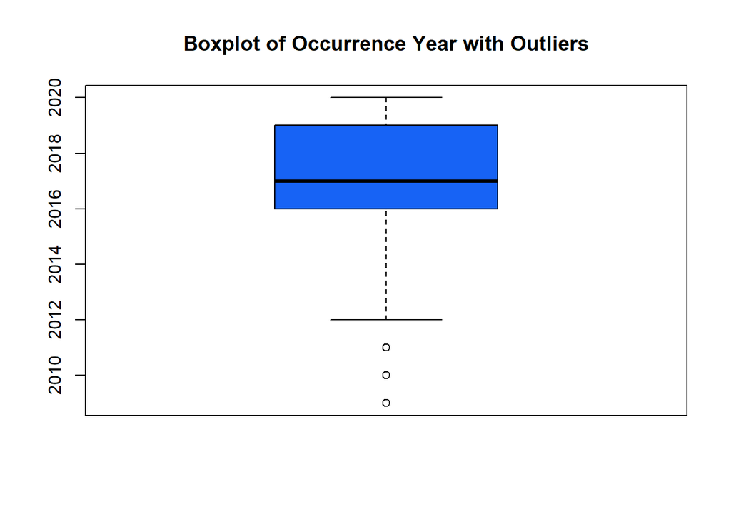

```r
boxplot(bicycle_theft$Occurrence_Year, col = "#1763F5", main = "Boxplot of Occurrence Year with Outliers")
```

```r
table(bt$Occurrence_Year)
```

```
##
## 2014 2015 2016 2017 2018 2019 2020
## 3085 3289 3813 3872 3960 3717 3833
```

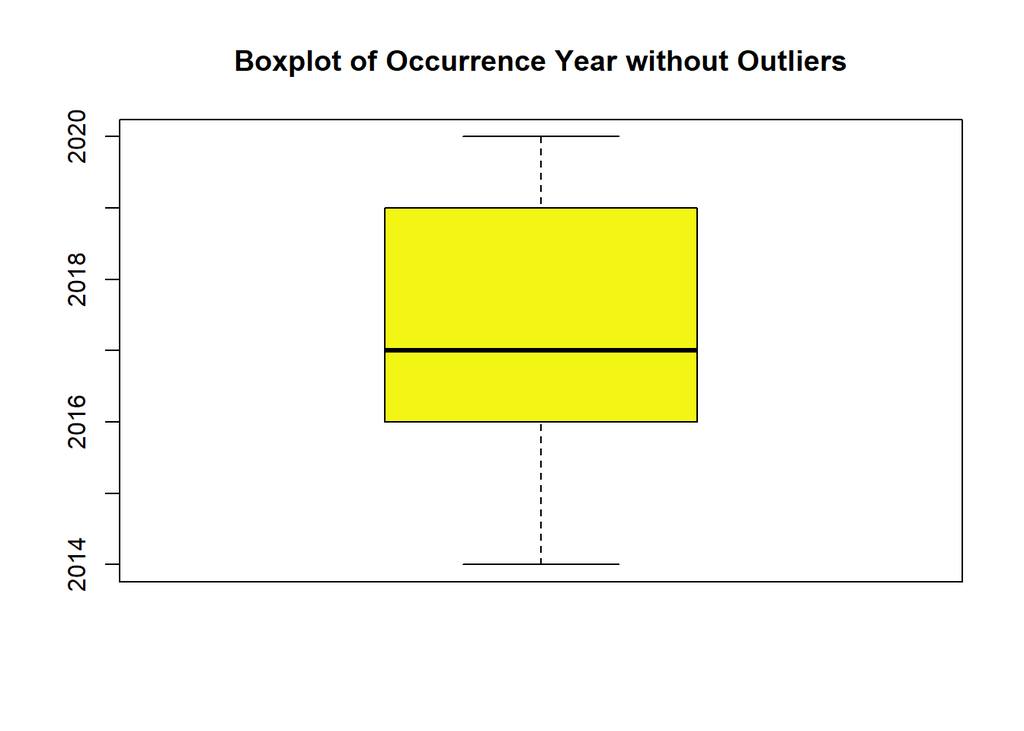

```r
boxplot(bt$Occurrence_Year, col = "#F3F515", main = "Boxplot of Occurrence Year without Outliers")
```

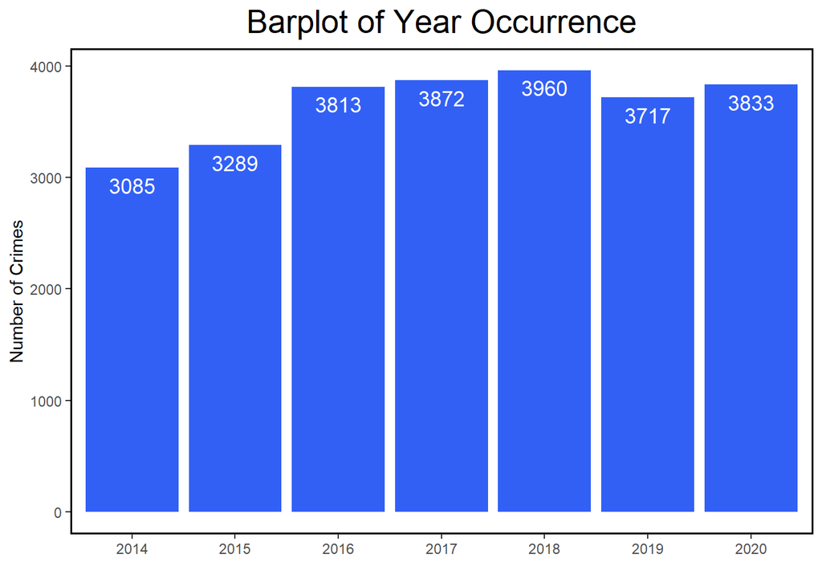

```r
year_occurrence<- table(bt$Occurrence_Year)
year_occurrence<- data.frame(year_occurrence)
colnames(year_occurrence)<- c("Year", "TotalNumber")

ggplot(year_occurrence, aes(x = Year, y = TotalNumber))+geom_bar(stat = "identity", fill= c("#3260F5"))+theme(panel.border = element_rect(colour = "black", fill=NA, size=1), panel.background = element_blank(), panel.grid.major = element_blank(), panel.grid.minor = element_blank(),axis.text.x = element_text(angle = 0), plot.title = element_text(size = 20, hjust = 0.5))+geom_text(aes(label = TotalNumber), vjust = 1.6, color = "white", size = 4.5)+labs(title = "Barplot of Year Occurrence", x = "", y = "Number of Crimes")
```

Column Occurrence_Month analysis

```r
bt$Occurrence_Month<- as.factor(bt$Occurrence_Month)
levels(bt$Occurrence_Month)
```

```
##  [1] "April"     "August"    "December"  "February"  "January"   "July"
##  [7] "June"      "March"     "May"       "November"  "October"   "September"
```

```r
bt$Occurrence_Month<- ordered(bt$Occurrence_Month, levels = c("January", "February", "March", "April","May","June", "July", "August", "September", "October", "November", "December"))
levels(bt$Occurrence_Month)
```

```
##  [1] "January"   "February"  "March"     "April"     "May"       "June"
##  [7] "July"      "August"    "September" "October"   "November"  "December"
```

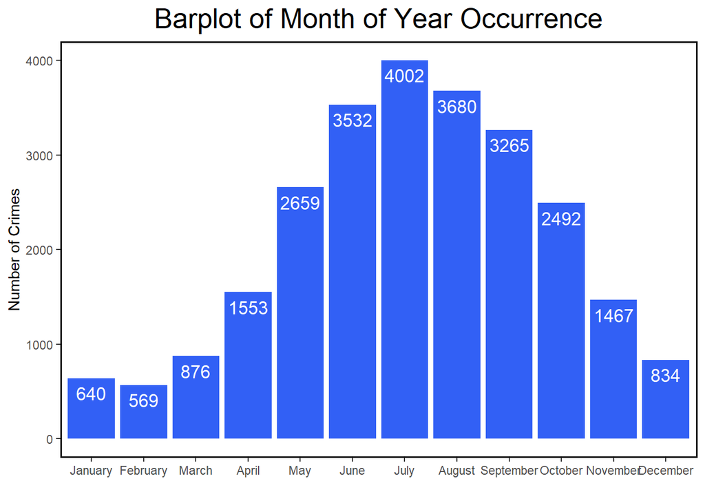

```r
month_occurrence<- table(bt$Occurrence_Month)
month_occurrence<- data.frame(month_occurrence)
colnames(month_occurrence)<- c("Month", "TotalNumber")

ggplot(month_occurrence, aes(x = Month, y = TotalNumber))+geom_bar(stat = "identity", fill= c("#3260F5"))+theme(panel.border = element_rect(colour = "black", fill=NA, size=1), panel.background = element_blank(), panel.grid.major = element_blank(), panel.grid.minor = element_blank(),axis.text.x = element_text(angle = 0), plot.title = element_text(size = 20, hjust = 0.5))+geom_text(aes(label = TotalNumber), vjust = 1.6, color = "white", size = 4.5)+labs(title = "Barplot of Month of Year Occurrence", x = "", y = "Number of Crimes")
```

Occurrence_Year vs Occurrence_Month analysis analysis

```r
year_month<- table(bt$Occurrence_Month, bt$Occurrence_Year)
year_month
```

```
##
##             2014 2015 2016 2017 2018 2019 2020
##   January     49   68  107   91   89  122  114
##   February    30   33  112  105  101   68  120
##   March       58   97  147  139  132  118  185
##   April      147  269  234  267  207  189  240
##   May        329  439  412  400  426  347  306
##   June       556  414  492  496  581  486  507
##   July       558  501  513  552  644  612  622
##   August     438  446  544  490  607  542  613
##   September  405  398  546  495  457  477  487
##   October    272  278  338  446  387  414  357
##   November   126  204  252  282  196  210  197
##   December   117  142  116  109  133  132   85
```

```r
January<- c(49, 68, 107, 91, 89, 122, 114)
February<-c(30, 33, 112, 105, 101, 68, 120)
March<-c(58, 97, 147, 139, 132, 118, 185)
April<- c(147, 269, 234, 267, 207, 189, 240)
May<-c(329, 439, 412, 400, 426, 347, 306)
June<-c( 556, 414, 492, 496, 581, 486, 507)
July<-c(558, 501, 513, 552, 644, 612, 622)
August<-c(438, 446, 544, 490, 607, 542, 613)
September<-c(405, 398, 546, 495, 457, 477, 487)
October<-c(272, 278, 338, 446, 387, 414, 357)
November<-c(126, 204, 252, 282, 196, 210, 197)
December<-c(117, 142, 116, 109, 133, 132, 85)

Combined_Months<- data.frame(cbind(January, February, March, April, May, June, July, August, September, October, November, December))
Stacked_Months<- stack(Combined_Months)
summary(Combined_Months)
```

```
##     January          February          March           April
##  Min.   : 49.00   Min.   : 30.00   Min.   : 58.0   Min.   :147.0
##  1st Qu.: 78.50   1st Qu.: 50.50   1st Qu.:107.5   1st Qu.:198.0
##  Median : 91.00   Median :101.00   Median :132.0   Median :234.0
##  Mean   : 91.43   Mean   : 81.29   Mean   :125.1   Mean   :221.9
##  3rd Qu.:110.50   3rd Qu.:108.50   3rd Qu.:143.0   3rd Qu.:253.5
##  Max.   :122.00   Max.   :120.00   Max.   :185.0   Max.   :269.0
##       May             June            July           August
##  Min.   :306.0   Min.   :414.0   Min.   :501.0   Min.   :438.0
##  1st Qu.:338.0   1st Qu.:489.0   1st Qu.:532.5   1st Qu.:468.0
##  Median :400.0   Median :496.0   Median :558.0   Median :542.0
##  Mean   :379.9   Mean   :504.6   Mean   :571.7   Mean   :525.7
##  3rd Qu.:419.0   3rd Qu.:531.5   3rd Qu.:617.0   3rd Qu.:575.5
##  Max.   :439.0   Max.   :581.0   Max.   :644.0   Max.   :613.0
##    September        October         November        December
##  Min.   :398.0   Min.   :272.0   Min.   :126.0   Min.   : 85.0
##  1st Qu.:431.0   1st Qu.:308.0   1st Qu.:196.5   1st Qu.:112.5
##  Median :477.0   Median :357.0   Median :204.0   Median :117.0
##  Mean   :466.4   Mean   :356.0   Mean   :209.6   Mean   :119.1
##  3rd Qu.:491.0   3rd Qu.:400.5   3rd Qu.:231.0   3rd Qu.:132.5
##  Max.   :546.0   Max.   :446.0   Max.   :282.0   Max.   :142.0
```

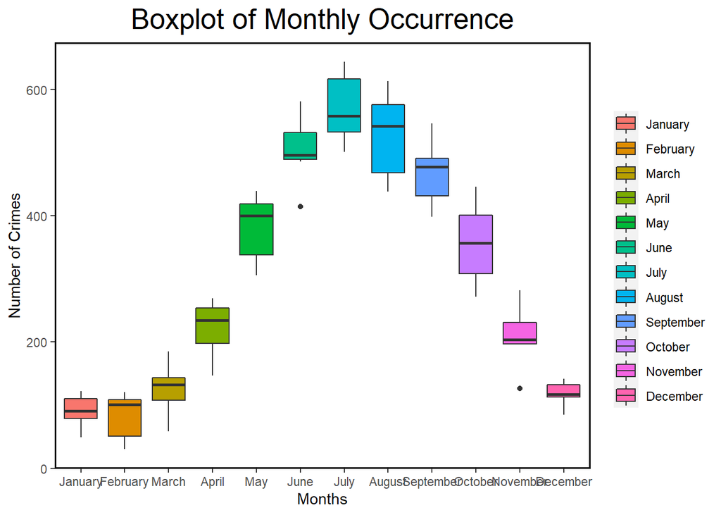

```r
ggplot(Stacked_Months, aes(ind, values, fill = ind))+geom_boxplot()+theme(panel.border = element_rect(colour = "black", fill=NA, size=1), panel.background = element_blank(), panel.grid.major = element_blank(), panel.grid.minor = element_blank(),axis.text.x = element_text(angle = 0), plot.title = element_text(size = 20, hjust = 0.5),legend.title = element_blank())+labs(title = "Boxplot of Monthly Occurrence", x = "Months", y = "Number of Crimes")
```

Column Occurrence_Day_of_Week analysis

```r
year_week<- table(bt$Occurrence_DayOfWeek, bt$Occurrence_Year)
bt$Occurrence_DayOfWeek<- as.factor(bt$Occurrence_DayOfWeek)
levels(bt$Occurrence_DayOfWeek)
```

```
## [1] "Friday"    "Monday"    "Saturday"  "Sunday"    "Thursday"  "Tuesday"
## [7] "Wednesday"
```

```r
bt$Occurrence_DayOfWeek<- ordered(bt$Occurrence_DayOfWeek, levels = c("Monday", "Tuesday", "Wednesday", "Thursday","Friday","Saturday", "Sunday" ))
levels(bt$Occurrence_DayOfWeek)
```

```
## [1] "Monday"    "Tuesday"   "Wednesday" "Thursday"  "Friday"    "Saturday"
## [7] "Sunday"
```

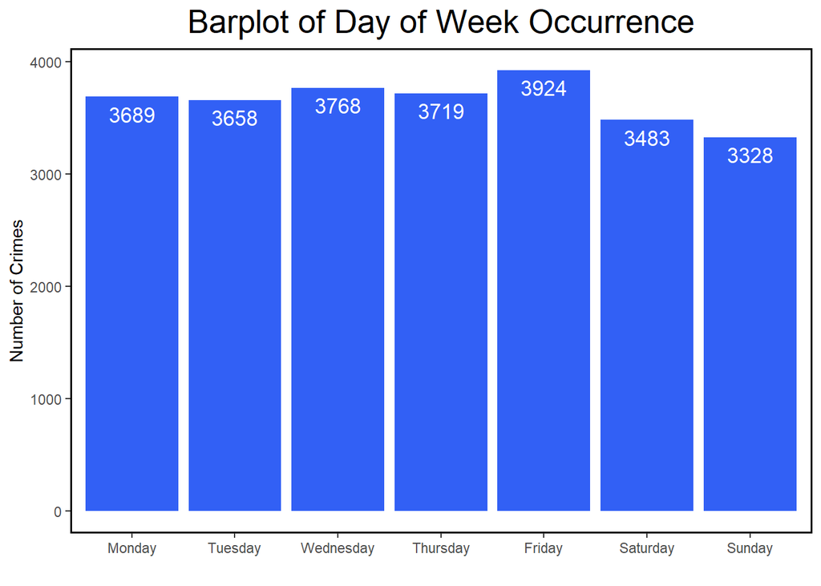

```r
days_of_week<- table(bt$Occurrence_DayOfWeek)
days_of_week<- data.frame(days_of_week)
colnames(days_of_week)<- c("Day", "TotalNumber")

ggplot(days_of_week, aes(x = Day, y = TotalNumber))+geom_bar(stat = "identity", fill= c("#3260F5"))+theme(panel.border = element_rect(colour = "black", fill=NA, size=1), panel.background = element_blank(), panel.grid.major = element_blank(), panel.grid.minor = element_blank(),axis.text.x = element_text(angle = 0), plot.title = element_text(size = 20, hjust = 0.5))+geom_text(aes(label = TotalNumber), vjust = 1.6, color = "white", size = 4.5)+labs(title = "Barplot of Day of Week Occurrence", x = "", y = "Number of Crimes")
```

Column Occurrence_Hour_of_Day analysis

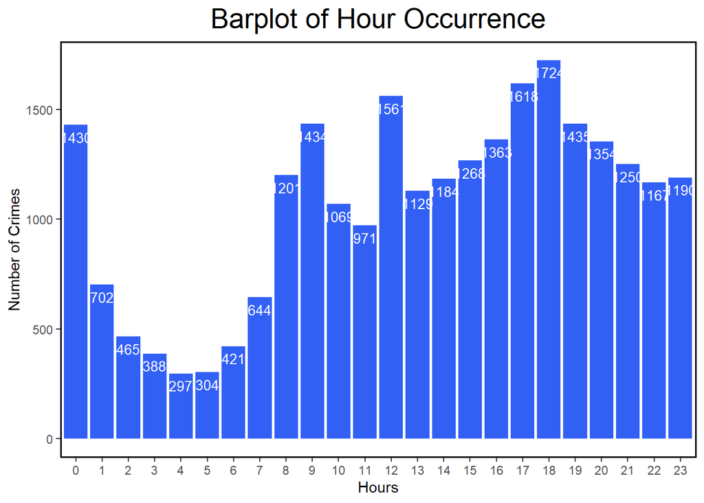

```r
bike_hours<- table(bt$Occurrence_Hour)
bike_hours<- data.frame((bike_hours))
colnames(bike_hours)<- c("Hours", "TotalNumber")

ggplot(bike_hours, aes(x = Hours, y = TotalNumber))+geom_bar(stat = "identity", fill= c("#3260F5"))+theme(panel.border = element_rect(colour = "black", fill=NA, size=1), panel.background = element_blank(), panel.grid.major = element_blank(), panel.grid.minor = element_blank(), axis.text.x = element_text(angle = 0), plot.title = element_text(size = 20, hjust = 0.5))+geom_text(aes(label = TotalNumber), vjust = 1.6, color = "white", size = 3.5)+labs(title = "Barplot of Hour Occurrence", x = "Hours", y = "Number of Crimes")
```

Column Division analysis

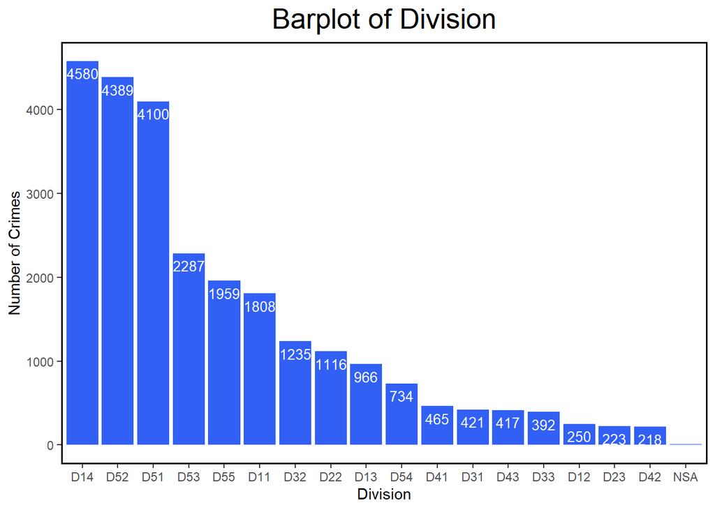

```r
division<- table(bt$Division)
division<- data.frame(division)
colnames(division)<- c("Division", "TotalNumber")

ggplot(division, aes(x = reorder(Division, -TotalNumber), y = TotalNumber))+geom_bar(stat = "identity", fill= c("#3260F5"))+theme(panel.border = element_rect(colour = "black", fill=NA, size=1), panel.background = element_blank(), panel.grid.major = element_blank(), panel.grid.minor = element_blank(), axis.text.x = element_text(angle = 0), plot.title = element_text(size = 20, hjust = 0.5))+geom_text(aes(label = TotalNumber), vjust = 1.6, color = "white", size = 3.5)+labs(title = "Barplot of Division", x = "Division", y = "Number of Crimes")
```

Column NeighbourhoodName analysis

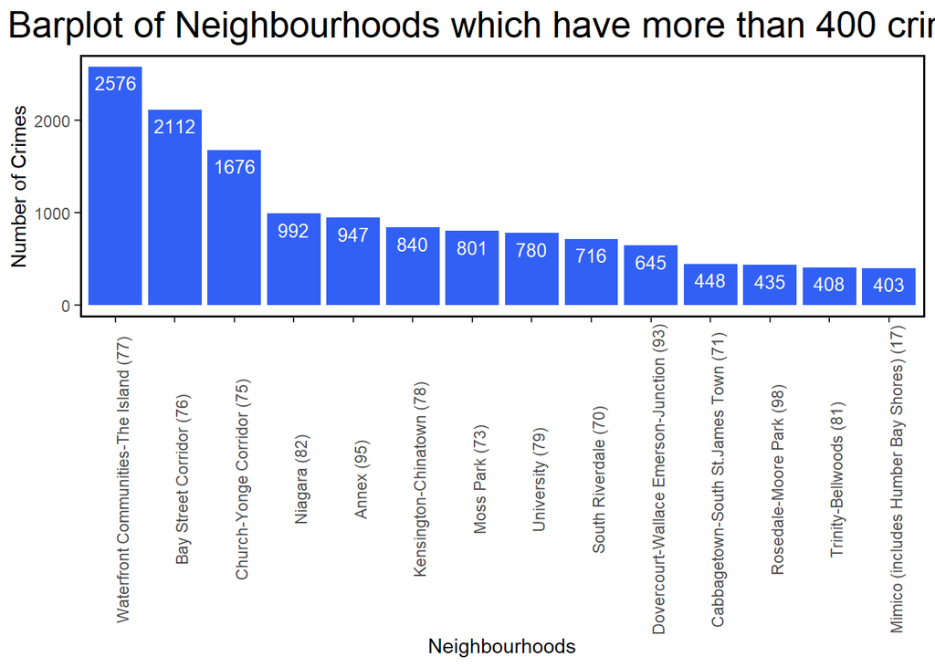

```r
hoods<- table(bt$NeighbourhoodName)

hoods<- data.frame(hoods, stringsAsFactors = F)
colnames(hoods)<- c("Name", "TotalNumber")
max_hoods<- filter(hoods, TotalNumber>400)
min_hoods<- filter(hoods, TotalNumber<30)

ggplot(max_hoods, aes(x = reorder(Name, -TotalNumber), y = TotalNumber))+geom_bar(stat = "identity", fill= c("#3260F5"))+theme(panel.border = element_rect(colour = "black", fill=NA, size=1), panel.background = element_blank(), panel.grid.major = element_blank(), panel.grid.minor = element_blank(), axis.text.x = element_text(angle = 90), plot.title = element_text(size = 20, hjust = 0.5))+geom_text(aes(label = TotalNumber), vjust = 1.6, color = "white", size = 3.5)+labs(title = "Barplot of Neighbourhoods which have more than 400 crimes", x = "Neighbourhoods", y = "Number of Crimes")
```

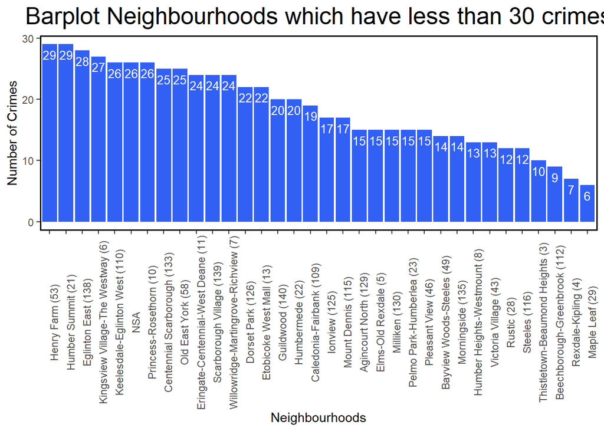

```r
ggplot(min_hoods, aes(x = reorder(Name, -TotalNumber), y = TotalNumber))+geom_bar(stat = "identity", fill= c("#3260F5"))+theme(panel.border = element_rect(colour = "black", fill=NA, size=1), panel.background = element_blank(), panel.grid.major = element_blank(), panel.grid.minor = element_blank(), axis.text.x = element_text(angle = 90), plot.title = element_text(size = 20, hjust = 0.5))+geom_text(aes(label = TotalNumber), vjust = 1.6, color = "white", size = 3.5)+labs(title = "Barplot Neighbourhoods which have less than 30 crimes", x = "Neighbourhoods", y = "Number of Crimes")
```

Column Location_Type analysis

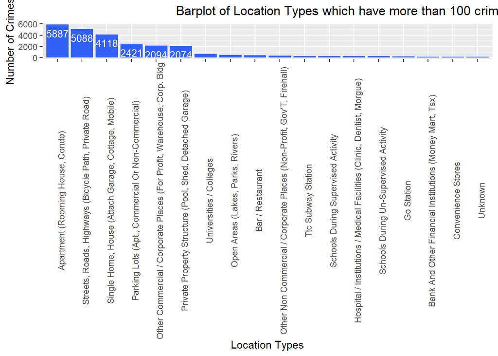

```r
location_type<- table(bt$Location_Type)
location_type<- data.frame(location_type)
colnames(location_type)<- c("Type", "TotalNumber")

max_location_type<- filter(location_type, TotalNumber>100)

ggplot(max_location_type, aes(x = reorder(Type, -TotalNumber), y = TotalNumber))+geom_bar(stat = "identity", fill= c("#3260F5"))+theme(axis.text.x = element_text(angle = 90))+geom_text(aes(label = TotalNumber), vjust = 1.6, color = "white", size = 3.5)+labs(title = "                                    Barplot of Location Types which have more than 100 crimes", x = "Location Types", y = "Number of Crimes")
```

Column Primary_Offence analysis

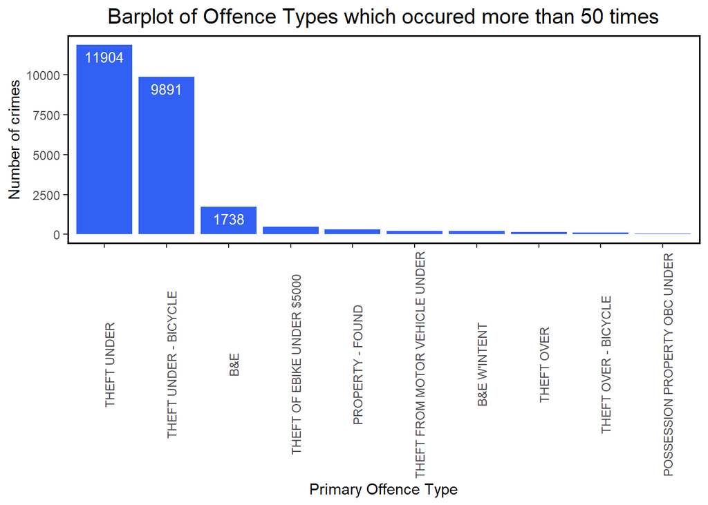

```r
offence_type<- table(bt$Primary_Offence)
offence_type<- data.frame(offence_type)
colnames(offence_type)<- c("Type", "TotalNumber")

max_offence_type<-filter(offence_type, TotalNumber>50)

ggplot(max_offence_type, aes(x = reorder(Type, -TotalNumber), y = TotalNumber))+geom_bar(stat = "identity", fill= c("#3260F5"))+theme(panel.border = element_rect(colour = "black", fill=NA, size=1), panel.background = element_blank(), panel.grid.major = element_blank(), panel.grid.minor = element_blank(), axis.text.x = element_text(angle = 90), plot.title = element_text(size = 15, hjust = 0.5))+geom_text(aes(label = TotalNumber), vjust = 1.6, color = "white", size = 3.5)+labs(title = "Barplot of Offence Types which occured more than 50 times", x = "Primary Offence Type", y = "Number of crimes")
```

Column Premises_Type analysis

```r
table(bt$Premises_Type)
```

```
##
##   Apartment  Commercial Educational       House       Other     Outside
##        5887        2953        1193        4118        2937        7960
##     Transit
##         521
```

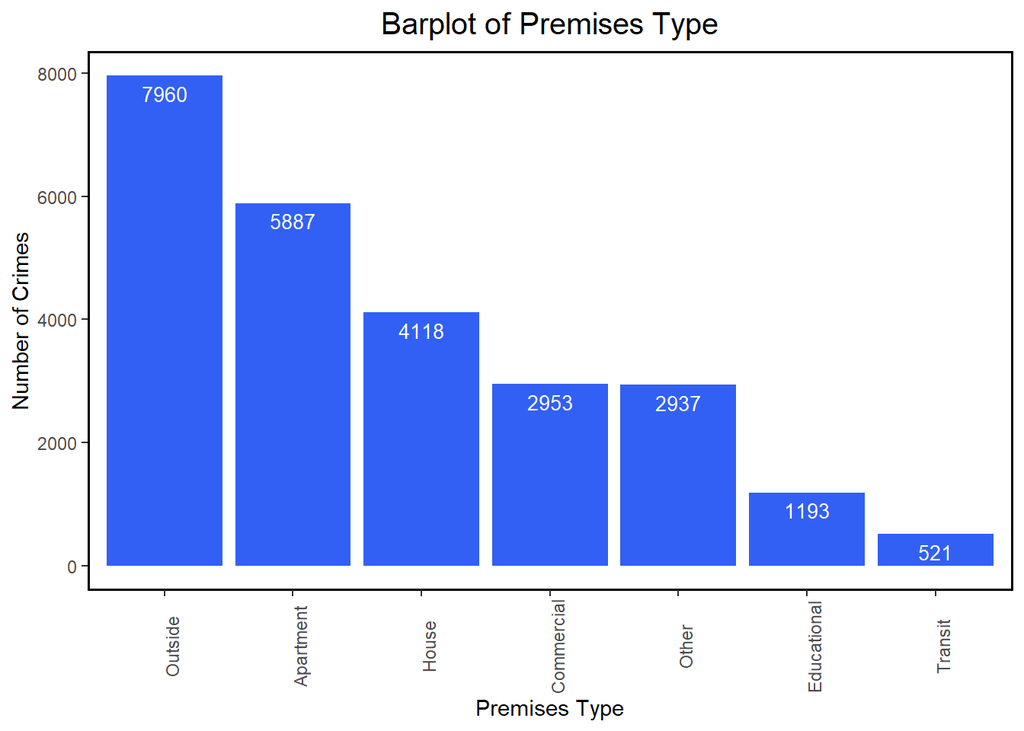

```r
premises_type<- table(bt$Premises_Type)
premises_type<- data.frame(premises_type)
colnames(premises_type)<- c("Type", "TotalNumber")

ggplot(premises_type, aes(x = reorder(Type, -TotalNumber), y = TotalNumber))+geom_bar(stat = "identity", fill= c("#3260F5"))+theme(panel.border = element_rect(colour = "black", fill=NA, size=1), panel.background = element_blank(), panel.grid.major = element_blank(), panel.grid.minor = element_blank(), axis.text.x = element_text(angle = 90), plot.title = element_text(size = 15, hjust = 0.5))+geom_text(aes(label = TotalNumber), vjust = 1.6, color = "white", size = 3.5)+labs(title = "Barplot of Premises Type", x = "Premises Type", y = "Number of Crimes")
```

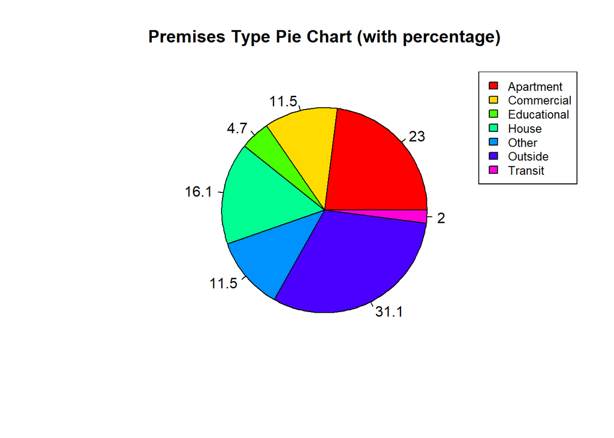

```r
piepercent<- round(100*premises_type$TotalNumber/sum(premises_type$TotalNumber), 1)
pie(premises_type$TotalNumber, labels = piepercent, main = "Premises Type Pie Chart (with percentage)", col = rainbow(length(premises_type$TotalNumber)))
legend("topright", c("Apartment","Commercial","Educational","House", "Other", "Outside", "Transit"), cex = 0.8, fill = rainbow(length(premises_type$TotalNumber)))
```

Column Bike_Make analysis

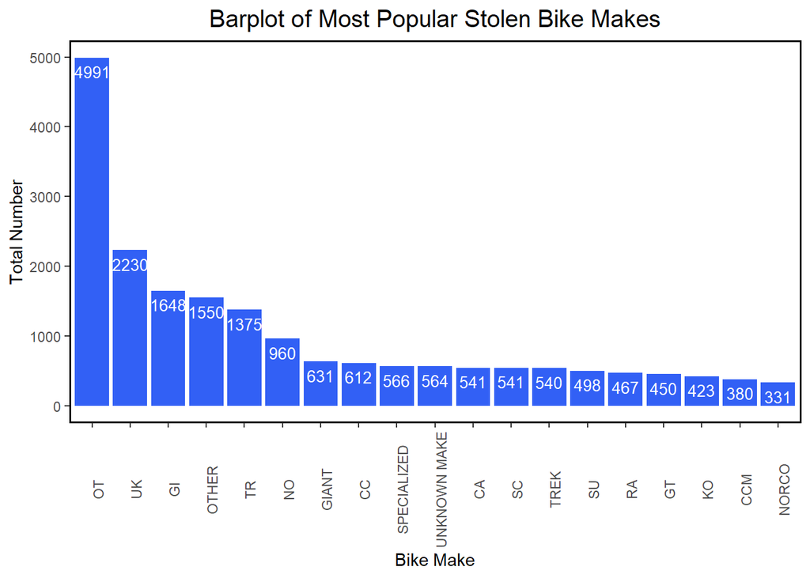

```r
bike_make<- table(bt$Bike_Make)
bike_make<- data.frame(table(bt$Bike_Make))
colnames(bike_make)<- c("Make", "TotalNumber")

max_bike_make<- filter(bike_make, TotalNumber>300)

ggplot(max_bike_make, aes(x = reorder(Make, -TotalNumber), y = TotalNumber))+geom_bar(stat = "identity", fill= c("#3260F5"))+theme(panel.border = element_rect(colour = "black", fill=NA, size=1), panel.background = element_blank(), panel.grid.major = element_blank(), panel.grid.minor = element_blank(), axis.text.x = element_text(angle = 90), plot.title = element_text(size = 15, hjust = 0.5))+geom_text(aes(label = TotalNumber), vjust = 1.6, color = "white", size = 3.5)+labs(title = "Barplot of Most Popular Stolen Bike Makes", x = "Bike Make", y = "Total Number")
```

Column Bike_Type analysis

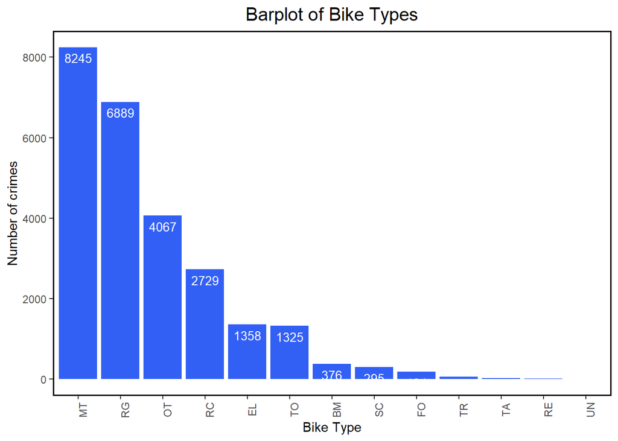

```r
bike_type<- table(bt$Bike_Type)
bike_type<- data.frame(bike_type)
colnames(bike_type)<- c("BikeType", "TotalNumber")

ggplot(bike_type, aes(x = reorder(BikeType, -TotalNumber), y = TotalNumber))+geom_bar(stat = "identity", fill= c("#3260F5"))+theme(panel.border = element_rect(colour = "black", fill=NA, size=1), panel.background = element_blank(), panel.grid.major = element_blank(), panel.grid.minor = element_blank(), axis.text.x = element_text(angle = 90), plot.title = element_text(size = 15, hjust = 0.5))+geom_text(aes(label = TotalNumber), vjust = 1.6, color = "white", size = 3.5)+labs(title = "Barplot of Bike Types", x = "Bike Type", y = "Number of crimes")
```

Column Status analysis

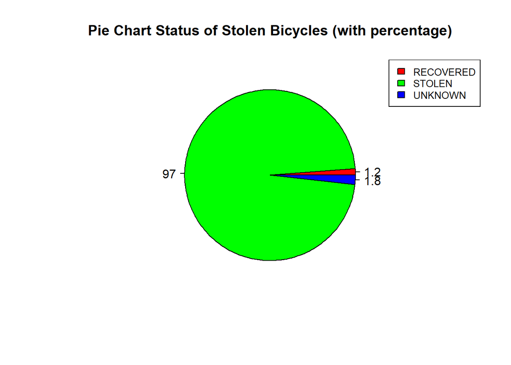

```r
bike_status<-table(bt$Status)
bike_status<- data.frame(bike_status)
colnames(bike_status)<- c("Status", "TotalNumber")

piepercent<- round(100*bike_status$TotalNumber/sum(bike_status$TotalNumber), 1)
pie(bike_status$TotalNumber, labels = piepercent, main = "Pie Chart Status of Stolen Bicycles (with percentage)", col = rainbow(length(bike_status$TotalNumber)))
legend("topright", c("RECOVERED","STOLEN","UNKNOWN"), cex = 0.8, fill = rainbow(length(bike_status$TotalNumber)))
```

___________________________________________Building Model_______________________________________________________

```
                                    First Model Random Forest
```

Data loading

```r
bicycle_theft <- read.csv(file = "bicycle-thefts.csv", header = T, stringsAsFactors = TRUE) #Loading data

str(bicycle_theft)
```

```
## 'data.frame':    25569 obs. of  33 variables:
##  $ X_id                 : int  1 2 3 4 5 6 7 8 9 10 ...
##  $ OBJECTID             : int  17744 17759 17906 17962 17963 18003 18013 20993 21209 21999 ...
##  $ event_unique_id      : Factor w/ 22771 levels "GO-20141261431",..: 12055 9819 15494 3936 4321 3504 7151 17005 11733 1456 ...
##  $ Primary_Offence      : Factor w/ 66 levels "AGGRAVATED ASLT PEACE OFFICER",..: 59 60 60 59 59 59 59 59 59 59 ...
##  $ Occurrence_Date      : Factor w/ 2501 levels "2009-09-01T00:00:00",..: 1346 1382 1678 478 487 595 762 1902 1319 139 ...
##  $ Occurrence_Year      : int  2017 2017 2018 2015 2015 2015 2016 2019 2017 2014 ...
##  $ Occurrence_Month     : Factor w/ 12 levels "April","August",..: 11 10 12 9 9 12 4 9 12 9 ...
##  $ Occurrence_DayOfWeek : Factor w/ 7 levels "Friday","Monday",..: 6 7 1 5 3 6 5 7 7 7 ...
##  $ Occurrence_DayOfMonth: int  3 8 14 7 16 1 18 1 6 7 ...
##  $ Occurrence_DayOfYear : int  276 312 257 127 136 244 49 121 249 127 ...
##  $ Occurrence_Hour      : int  14 3 9 18 12 0 9 13 8 18 ...
##  $ Report_Date          : Factor w/ 2468 levels "2014-01-01T00:00:00",..: 1308 1344 1646 450 452 618 727 1870 1281 102 ...
##  $ Report_Year          : int  2017 2017 2018 2015 2015 2015 2016 2019 2017 2014 ...
##  $ Report_Month         : Factor w/ 12 levels "April","August",..: 11 10 12 9 9 11 4 9 12 9 ...
```

[output cut: 19 more lines]

```r
bt_clean<- bicycle_theft
bt_clean$event_unique_id<- as.character(bt_clean$event_unique_id)
bt_clean$Occurrence_Date<- as.Date(bt_clean$Occurrence_Date)
bt_clean$Report_Date<- as.Date(bt_clean$Report_Date)
bt_clean$Primary_Offence<- as.character(bt_clean$Primary_Offence)
bt_clean$Occurrence_Year<- as.numeric(bt_clean$Occurrence_Year)
bt_clean$Occurrence_Month<- as.factor(bt_clean$Occurrence_Month)
bt_clean$Occurrence_DayOfWeek<- as.factor(bt_clean$Occurrence_DayOfWeek)
bt_clean$Occurrence_Hour<- as.factor(bt_clean$Occurrence_Hour)
bt_clean$Division<- as.factor(bt_clean$Division)
bt_clean$Hood_ID<- as.integer(bt_clean$Hood_ID)
bt_clean$NeighbourhoodName<- as.character(bt_clean$NeighbourhoodName)
bt_clean$Location_Type<- as.factor(bt_clean$Location_Type)
bt_clean$Premises_Type<- as.factor(bt_clean$Premises_Type)
bt_clean$Bike_Make<- as.character(bt_clean$Bike_Make)
bt_clean$Bike_Model<- as.character(bt_clean$Bike_Model)
bt_clean$Bike_Type<- as.factor(bt_clean$Bike_Type)
bt_clean$Cost_of_Bike<- as.numeric(bt_clean$Cost_of_Bike)
bt_clean$Status<- as.factor(bt_clean$Status)
bt_clean$Bike_Colour<-as.character(bt_clean$Bike_Colour)
str(bt_clean)
```

```
## 'data.frame':    25569 obs. of  33 variables:
##  $ X_id                 : int  1 2 3 4 5 6 7 8 9 10 ...
##  $ OBJECTID             : int  17744 17759 17906 17962 17963 18003 18013 20993 21209 21999 ...
##  $ event_unique_id      : chr  "GO-20179016397" "GO-20172033056" "GO-20189030822" "GO-2015804467" ...
##  $ Primary_Offence      : chr  "THEFT UNDER" "THEFT UNDER - BICYCLE" "THEFT UNDER - BICYCLE" "THEFT UNDER" ...
##  $ Occurrence_Date      : Date, format: "2017-10-03" "2017-11-08" ...
##  $ Occurrence_Year      : num  2017 2017 2018 2015 2015 ...
##  $ Occurrence_Month     : Factor w/ 12 levels "April","August",..: 11 10 12 9 9 12 4 9 12 9 ...
##  $ Occurrence_DayOfWeek : Factor w/ 7 levels "Friday","Monday",..: 6 7 1 5 3 6 5 7 7 7 ...
##  $ Occurrence_DayOfMonth: int  3 8 14 7 16 1 18 1 6 7 ...
##  $ Occurrence_DayOfYear : int  276 312 257 127 136 244 49 121 249 127 ...
##  $ Occurrence_Hour      : Factor w/ 24 levels "0","1","2","3",..: 15 4 10 19 13 1 10 14 9 19 ...
##  $ Report_Date          : Date, format: "2017-10-03" "2017-11-08" ...
##  $ Report_Year          : int  2017 2017 2018 2015 2015 2015 2016 2019 2017 2014 ...
##  $ Report_Month         : Factor w/ 12 levels "April","August",..: 11 10 12 9 9 11 4 9 12 9 ...
```

[output cut: 19 more lines]

Reducing the levels of rating for NeigbourhoodName based on quantile method

```r
Neighbourhoods<- table(bt_clean$NeighbourhoodName)
Neighbourhoods<- data.frame(Neighbourhoods, stringsAsFactors = F)
colnames(Neighbourhoods)<- c("NeighbourhoodName", "TotalNumber")

quantcut(Neighbourhoods$TotalNumber, 5)
```

```
##   [1] [6,26]         (26,49]        (26,49]        (221,2.58e+03] (26,49]
##   [6] (26,49]        (221,2.58e+03] (94,221]       [6,26]         (94,221]
##  [11] [6,26]         (49,94]        (49,94]        (26,49]        (49,94]
##  [16] (49,94]        (26,49]        (49,94]        (26,49]        (221,2.58e+03]
##  [21] [6,26]         (94,221]       [6,26]         (221,2.58e+03] (49,94]
##  [26] (26,49]        (26,49]        (49,94]        (94,221]       (49,94]
##  [31] (26,49]        [6,26]         (221,2.58e+03] (94,221]       (221,2.58e+03]
##  [36] (221,2.58e+03] (26,49]        (26,49]        [6,26]         (94,221]
##  [41] [6,26]         [6,26]         (26,49]        (94,221]       (49,94]
##  [46] (49,94]        (221,2.58e+03] [6,26]         (26,49]        (221,2.58e+03]
##  [51] (221,2.58e+03] (26,49]        (26,49]        [6,26]         (26,49]
##  [56] [6,26]         (94,221]       [6,26]         (94,221]       (94,221]
##  [61] [6,26]         (26,49]        (221,2.58e+03] (26,49]        (49,94]
##  [66] (49,94]        (26,49]        (26,49]        (94,221]       (94,221]
##  [71] (94,221]       (221,2.58e+03] (94,221]       (26,49]        [6,26]
##  [76] (49,94]        [6,26]         (221,2.58e+03] [6,26]         (221,2.58e+03]
##  [81] [6,26]         (49,94]        (94,221]       (221,2.58e+03] (49,94]
##  [86] (26,49]        (94,221]       (221,2.58e+03] (94,221]       (221,2.58e+03]
##  [91] [6,26]         (49,94]        (94,221]       (49,94]        [6,26]
##  [96] (221,2.58e+03] (26,49]        [6,26]         (94,221]       [6,26]
## [101] [6,26]         (221,2.58e+03] [6,26]         (49,94]        (221,2.58e+03]
## [106] (221,2.58e+03] (49,94]        (94,221]       [6,26]         [6,26]
## [111] (221,2.58e+03] (221,2.58e+03] (26,49]        [6,26]         (49,94]
## [116] (26,49]        (49,94]        (221,2.58e+03] [6,26]         (49,94]
## [121] (221,2.58e+03] (221,2.58e+03] [6,26]         (221,2.58e+03] (94,221]
## [126] (49,94]        (49,94]        (49,94]        (49,94]        (49,94]
## [131] (221,2.58e+03] (94,221]       [6,26]         (49,94]        (26,49]
## [136] (94,221]       (94,221]       (94,221]       (94,221]       (94,221]
## [141] (94,221]
## Levels: [6,26] (26,49] (49,94] (94,221] (221,2.58e+03]
```

```r
Neighbourhoods$Hood_Risk<- ifelse(Neighbourhoods$TotalNumber<26, "Very Low", ifelse(Neighbourhoods$TotalNumber<49, "Low", ifelse(Neighbourhoods$TotalNumber<94, "Medium", ifelse(Neighbourhoods$TotalNumber<221, "High", "Very High"))))
Neighbourhoods_subset<- subset(Neighbourhoods, select = -TotalNumber)
bt_clean<- merge(bt_clean, Neighbourhoods_subset, by = "NeighbourhoodName")
bt_clean$Hood_Risk<- as.factor(bt_clean$Hood_Risk)
bt_clean$Hood_Risk<- ordered(bt_clean$Hood_Risk, c('Very Low', 'Low', 'Medium', 'High', 'Very High'))
table(Neighbourhoods$Hood_Risk)
```

```
##
##      High       Low    Medium Very High  Very Low
##        28        27        30        29        27
```

Future selection Chi-Squared method

```r
bt_clean_future_selection<- subset(bt_clean, select = -c(X_id,OBJECTID, event_unique_id,Occurrence_DayOfMonth,Occurrence_DayOfYear, Report_Date, Report_Year, Report_Month, Report_DayOfWeek, Report_DayOfMonth, Report_DayOfYear, Report_Hour, Bike_Speed, ObjectId2, geometry))

weights<- chi.squared(Hood_Risk~., bt_clean_future_selection)
print(weights)
```

```
##                      attr_importance
## NeighbourhoodName         1.00000000
## Primary_Offence           0.09678534
## Occurrence_Date           0.06247590
## Occurrence_Year           0.05551072
## Occurrence_Month          0.03519928
## Occurrence_DayOfWeek      0.01885487
## Occurrence_Hour           0.04283949
## Division                  0.52835003
## City                      0.09315657
## Hood_ID                   1.00000000
## Location_Type             0.17174662
## Premises_Type             0.12983312
## Bike_Make                 0.25231447
## Bike_Model                0.53933264
## Bike_Type                 0.10700994
## Bike_Colour               0.12385040
## Cost_of_Bike              0.09174120
## Status                    0.04588106
```

```r
subset<- cutoff.k(weights, 18)
f<- as.simple.formula(subset, "Hood_Risk")
print(f)
```

```
## Hood_Risk ~ NeighbourhoodName + Hood_ID + Bike_Model + Division +
##     Bike_Make + Location_Type + Premises_Type + Bike_Colour +
##     Bike_Type + Primary_Offence + City + Cost_of_Bike + Occurrence_Date +
##     Occurrence_Year + Status + Occurrence_Hour + Occurrence_Month +
##     Occurrence_DayOfWeek
## <environment: 0x00000000174d44b0>
```

Repeated cross-validation Method_1 on Random Forest

```r
set.seed(999)
data_1<- bt_clean_future_selection

#Random Sampling
Index<- sample(nrow(data_1), floor(0.70*nrow(data_1)))
data_1_train<- data_1[Index,]
data_1_test<- data_1[-Index,]

#Treating train data
data_1_train$Cost_of_Bike[is.na(data_1_train$Cost_of_Bike)]<- mean(data_1_train$Cost_of_Bike,na.rm=TRUE)
data_1_train$Occurrence_Year[data_1_train$Occurrence_Year==2009] <- 2014
data_1_train$Occurrence_Year[data_1_train$Occurrence_Year==2010] <- 2014
data_1_train$Occurrence_Year[data_1_train$Occurrence_Year==2011] <- 2014
data_1_train$Occurrence_Year[data_1_train$Occurrence_Year==2012] <- 2014
data_1_train$Occurrence_Year[data_1_train$Occurrence_Year==2013] <- 2014

ctrl_1<- trainControl(method = "repeatedcv", number = 10 ,repeats = 10)

#Building model
model_1_1<- randomForest(Hood_Risk~., data = data_1_train, ntree = 100, trainControl = ctrl_1, tuneLength = 5)
print(model_1_1)
```

```
##
## Call:
##  randomForest(formula = Hood_Risk ~ ., data = data_1_train, ntree = 100,      trainControl = ctrl_1, tuneLength = 5)
##                Type of random forest: classification
##                      Number of trees: 100
## No. of variables tried at each split: 4
##
##         OOB estimate of  error rate: 2.12%
## Confusion matrix:
##           Very Low Low Medium High Very High  class.error
## Very Low       150  37    113   19         1 0.5312500000
## Low              9 580     34   54         5 0.1495601173
## Medium           0   7   1422   36         1 0.0300136426
## High             0   9      5 2537        40 0.0208413740
## Very High        0   0      3    7     12829 0.0007788769
```

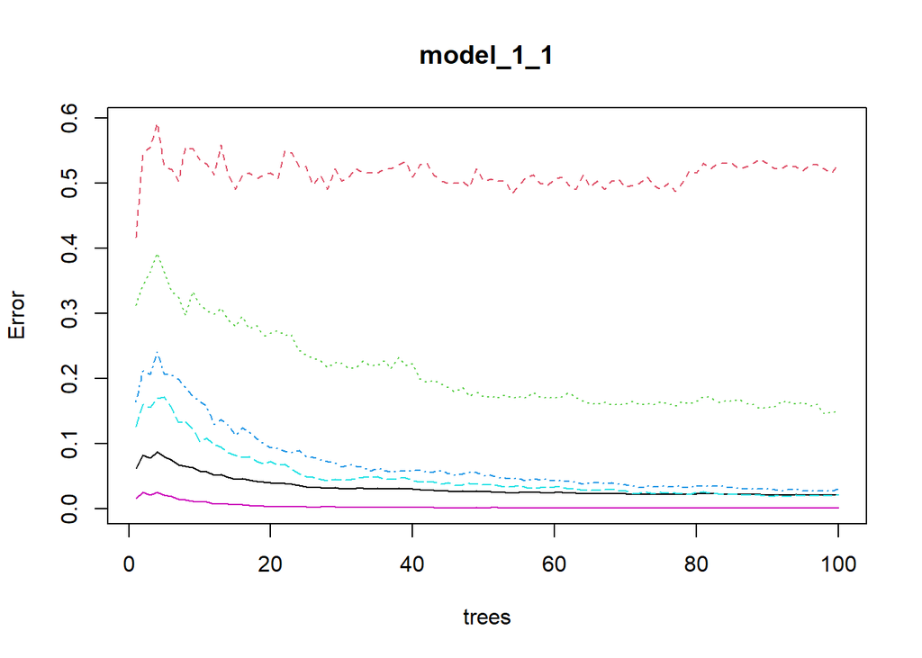

```r
plot(model_1_1)
```

```r
#Testing Model
risk_pred_model_1_1<- predict(model_1_1, data_1_test)

#Statistics about model
data_1_test$risk_pred_model_1_1<- risk_pred_model_1_1
conf_matrix_rfm_1_1<- table(data_1_test$Hood_Risk, data_1_test$risk_pred_model_1_1)
conf_matrix_rfm_1_1
```

```
##
##             Very Low  Low Medium High Very High
##   Very Low        53    9     41    3         0
##   Low              5  232     11   28         1
##   Medium           0    0    544    7         4
##   High             0    2      2  949        29
##   Very High        0    0      1    4      5232
```

```r
class_accuarcy_model_1_1<- sum(diag(conf_matrix_rfm_1_1)/sum(conf_matrix_rfm_1_1))
class_accuarcy_model_1_1
```

```
## [1] 0.9794607
```

```r
confusionMatrix(conf_matrix_rfm_1_1)
```

```
## Confusion Matrix and Statistics
##
##
##             Very Low  Low Medium High Very High
##   Very Low        53    9     41    3         0
##   Low              5  232     11   28         1
##   Medium           0    0    544    7         4
##   High             0    2      2  949        29
##   Very High        0    0      1    4      5232
##
## Overall Statistics
##
##                Accuracy : 0.9795
##                  95% CI : (0.9759, 0.9826)
##     No Information Rate : 0.7358
##     P-Value [Acc > NIR] : < 2.2e-16
##
##                   Kappa : 0.9527
##
##  Mcnemar's Test P-Value : NA
##
## Statistics by Class:
##
##                      Class: Very Low Class: Low Class: Medium Class: High
## Sensitivity                 0.913793    0.95473       0.90818      0.9576
## Specificity                 0.992534    0.99349       0.99832      0.9946
## Pos Pred Value              0.500000    0.83755       0.98018      0.9664
## Neg Pred Value              0.999291    0.99840       0.99167      0.9932
## Prevalence                  0.008104    0.03395       0.08369      0.1385
## Detection Rate              0.007405    0.03242       0.07601      0.1326
## Detection Prevalence        0.014811    0.03870       0.07755      0.1372
## Balanced Accuracy           0.953164    0.97411       0.95325      0.9761
##                      Class: Very High
## Sensitivity                    0.9935
## Specificity                    0.9974
## Pos Pred Value                 0.9990
## Neg Pred Value                 0.9823
## Prevalence                     0.7358
## Detection Rate                 0.7310
## Detection Prevalence           0.7317
## Balanced Accuracy              0.9954
```

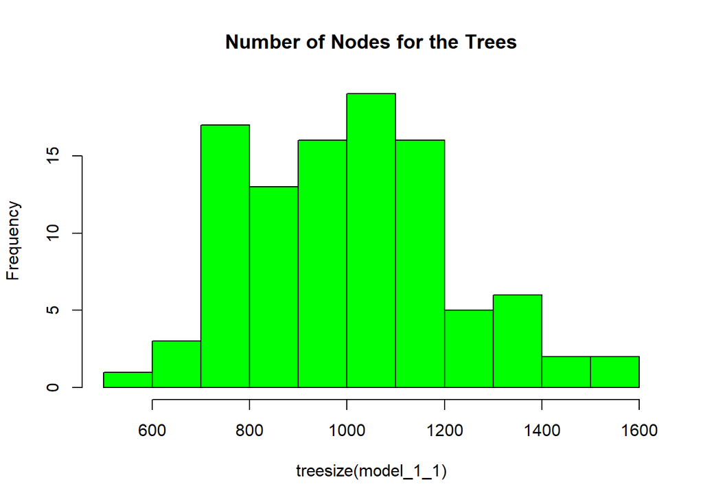

```r
hist(treesize(model_1_1), main = "Number of Nodes for the Trees", col = "green")
```

```r
varImpPlot(model_1_1, sort = TRUE, main = "Variable Importance")
```

[output not shown]

```r
importance(model_1_1)
```

```
##                      MeanDecreaseGini
## NeighbourhoodName         1586.333737
## Primary_Offence             63.024994
## Occurrence_Date            169.763510
## Occurrence_Year             72.263118
## Occurrence_Month           206.415005
## Occurrence_DayOfWeek       152.675406
## Occurrence_Hour            332.518537
## Division                  2018.622879
## City                         4.214652
## Hood_ID                   2553.234293
## Location_Type              250.743714
## Premises_Type              141.421714
## Bike_Make                  124.123655
## Bike_Model                  97.075958
## Bike_Type                  133.186791
## Bike_Colour                100.069529
## Cost_of_Bike               146.377560
## Status                       9.681667
```

Method_2 Leave one out cross validation - LOOCV on Random Forest

```r
set.seed(999)
data_1<- bt_clean_future_selection

#Random Sampling
Index<- sample(nrow(data_1), floor(0.70*nrow(data_1)))
data_1_train<- data_1[Index,]
data_1_test<- data_1[-Index,]

#Treating train data
data_1_train$Cost_of_Bike[is.na(data_1_train$Cost_of_Bike)]<- mean(data_1_train$Cost_of_Bike,na.rm=TRUE)
data_1_train$Occurrence_Year[data_1_train$Occurrence_Year==2009] <- 2014
data_1_train$Occurrence_Year[data_1_train$Occurrence_Year==2010] <- 2014
data_1_train$Occurrence_Year[data_1_train$Occurrence_Year==2011] <- 2014
data_1_train$Occurrence_Year[data_1_train$Occurrence_Year==2012] <- 2014
data_1_train$Occurrence_Year[data_1_train$Occurrence_Year==2013] <- 2014

ctrl_2<- trainControl(method = "LOCV")


#Building model
model_1_2<- randomForest(Hood_Risk~., data = data_1_train, ntree = 100, trainControl = ctrl_2, tuneLength = 5)
print(model_1_2)
```

```
##
## Call:
##  randomForest(formula = Hood_Risk ~ ., data = data_1_train, ntree = 100,      trainControl = ctrl_2, tuneLength = 5)
##                Type of random forest: classification
##                      Number of trees: 100
## No. of variables tried at each split: 4
##
##         OOB estimate of  error rate: 2.12%
## Confusion matrix:
##           Very Low Low Medium High Very High  class.error
## Very Low       150  37    113   19         1 0.5312500000
## Low              9 580     34   54         5 0.1495601173
## Medium           0   7   1422   36         1 0.0300136426
## High             0   9      5 2537        40 0.0208413740
## Very High        0   0      3    7     12829 0.0007788769
```

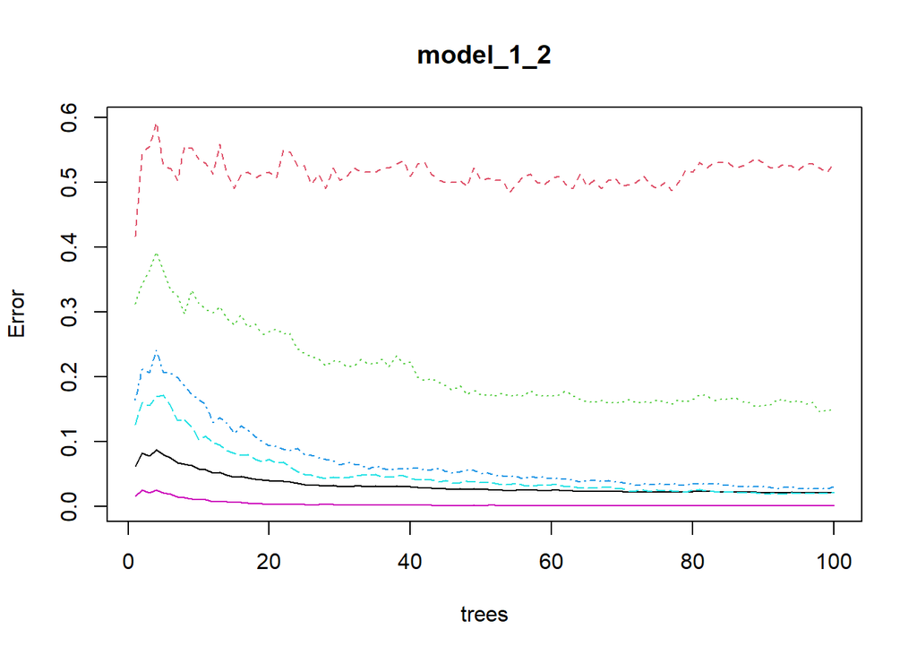

```r
plot(model_1_2)
```

```r
#Testing Model
risk_pred_model_1_2<- predict(model_1_2, data_1_test)


#Statistics about model
data_1_test$risk_pred_model_1_2<- risk_pred_model_1_2
conf_matrix_rfm_1_2<- table(data_1_test$Hood_Risk, data_1_test$risk_pred_model_1_2)
conf_matrix_rfm_1_2
```

```
##
##             Very Low  Low Medium High Very High
##   Very Low        53    9     41    3         0
##   Low              5  232     11   28         1
##   Medium           0    0    544    7         4
##   High             0    2      2  949        29
##   Very High        0    0      1    4      5232
```

```r
class_accuarcy_model_1_2<- sum(diag(conf_matrix_rfm_1_2)/sum(conf_matrix_rfm_1_2))
class_accuarcy_model_1_2
```

```
## [1] 0.9794607
```

```r
confusionMatrix(conf_matrix_rfm_1_2)
```

```
## Confusion Matrix and Statistics
##
##
##             Very Low  Low Medium High Very High
##   Very Low        53    9     41    3         0
##   Low              5  232     11   28         1
##   Medium           0    0    544    7         4
##   High             0    2      2  949        29
##   Very High        0    0      1    4      5232
##
## Overall Statistics
##
##                Accuracy : 0.9795
##                  95% CI : (0.9759, 0.9826)
##     No Information Rate : 0.7358
##     P-Value [Acc > NIR] : < 2.2e-16
##
##                   Kappa : 0.9527
##
##  Mcnemar's Test P-Value : NA
##
## Statistics by Class:
##
##                      Class: Very Low Class: Low Class: Medium Class: High
## Sensitivity                 0.913793    0.95473       0.90818      0.9576
## Specificity                 0.992534    0.99349       0.99832      0.9946
## Pos Pred Value              0.500000    0.83755       0.98018      0.9664
## Neg Pred Value              0.999291    0.99840       0.99167      0.9932
## Prevalence                  0.008104    0.03395       0.08369      0.1385
## Detection Rate              0.007405    0.03242       0.07601      0.1326
## Detection Prevalence        0.014811    0.03870       0.07755      0.1372
## Balanced Accuracy           0.953164    0.97411       0.95325      0.9761
##                      Class: Very High
## Sensitivity                    0.9935
## Specificity                    0.9974
## Pos Pred Value                 0.9990
## Neg Pred Value                 0.9823
## Prevalence                     0.7358
## Detection Rate                 0.7310
## Detection Prevalence           0.7317
## Balanced Accuracy              0.9954
```

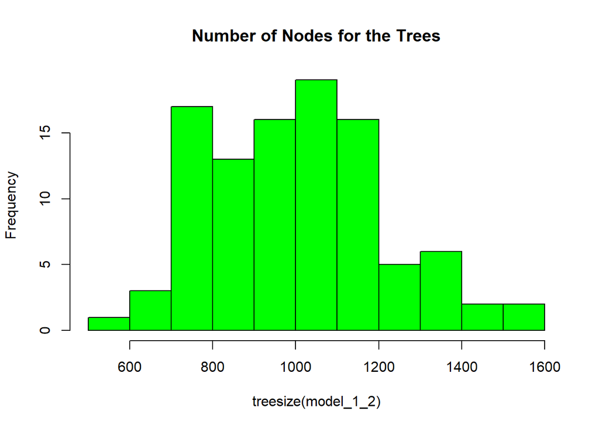

```r
hist(treesize(model_1_2), main = "Number of Nodes for the Trees", col = "green")
```

```r
varImpPlot(model_1_2, sort = TRUE, main = "Variable Importance")
```

[output not shown]

```r
importance(model_1_2)
```

```
##                      MeanDecreaseGini
## NeighbourhoodName         1586.333737
## Primary_Offence             63.024994
## Occurrence_Date            169.763510
## Occurrence_Year             72.263118
## Occurrence_Month           206.415005
## Occurrence_DayOfWeek       152.675406
## Occurrence_Hour            332.518537
## Division                  2018.622879
## City                         4.214652
## Hood_ID                   2553.234293
## Location_Type              250.743714
## Premises_Type              141.421714
## Bike_Make                  124.123655
## Bike_Model                  97.075958
## Bike_Type                  133.186791
## Bike_Colour                100.069529
## Cost_of_Bike               146.377560
## Status                       9.681667
```

Method_3 K-fold cross-validation on Random Forest

```r
set.seed(999)
data_1<- bt_clean_future_selection

#Random Sampling
Index<- sample(nrow(data_1), floor(0.70*nrow(data_1)))
data_1_train<- data_1[Index,]
data_1_test<- data_1[-Index,]

#Treating train data
data_1_train$Cost_of_Bike[is.na(data_1_train$Cost_of_Bike)]<- mean(data_1_train$Cost_of_Bike,na.rm=TRUE)
data_1_train$Occurrence_Year[data_1_train$Occurrence_Year==2009] <- 2014
data_1_train$Occurrence_Year[data_1_train$Occurrence_Year==2010] <- 2014
data_1_train$Occurrence_Year[data_1_train$Occurrence_Year==2011] <- 2014
data_1_train$Occurrence_Year[data_1_train$Occurrence_Year==2012] <- 2014
data_1_train$Occurrence_Year[data_1_train$Occurrence_Year==2013] <- 2014

ctrl_3<- trainControl(method = "cv", number = 10)

#Building model
model_1_3<- randomForest(Hood_Risk~., data = data_1_train, ntree = 100, trainControl = ctrl_3, tuneLength = 5)
print(model_1_3)
```

```
##
## Call:
##  randomForest(formula = Hood_Risk ~ ., data = data_1_train, ntree = 100,      trainControl = ctrl_3, tuneLength = 5)
##                Type of random forest: classification
##                      Number of trees: 100
## No. of variables tried at each split: 4
##
##         OOB estimate of  error rate: 2.12%
## Confusion matrix:
##           Very Low Low Medium High Very High  class.error
## Very Low       150  37    113   19         1 0.5312500000
## Low              9 580     34   54         5 0.1495601173
## Medium           0   7   1422   36         1 0.0300136426
## High             0   9      5 2537        40 0.0208413740
## Very High        0   0      3    7     12829 0.0007788769
```

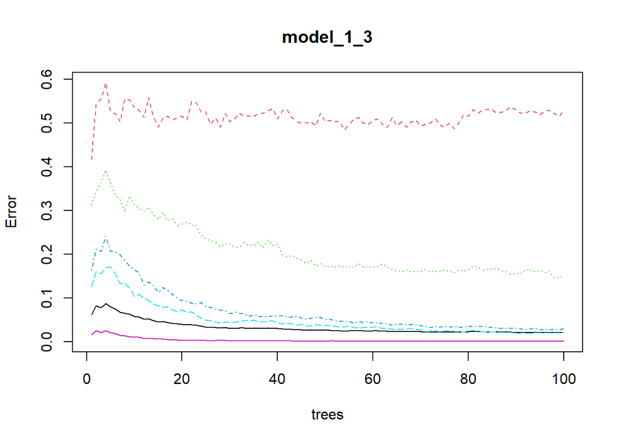

```r
plot(model_1_3)
```

```r
#Testing Model
risk_pred_model_1_3<- predict(model_1_3, data_1_test)



#Statistics about model
data_1_test$risk_pred_model_1_3<- risk_pred_model_1_3
conf_matrix_rfm_1_3<- table(data_1_test$Hood_Risk, data_1_test$risk_pred_model_1_3)
conf_matrix_rfm_1_3
```

```
##
##             Very Low  Low Medium High Very High
##   Very Low        53    9     41    3         0
##   Low              5  232     11   28         1
##   Medium           0    0    544    7         4
##   High             0    2      2  949        29
##   Very High        0    0      1    4      5232
```

```r
class_accuarcy_model_1_3<- sum(diag(conf_matrix_rfm_1_3)/sum(conf_matrix_rfm_1_3))
class_accuarcy_model_1_3
```

```
## [1] 0.9794607
```

```r
confusionMatrix(conf_matrix_rfm_1_3)
```

```
## Confusion Matrix and Statistics
##
##
##             Very Low  Low Medium High Very High
##   Very Low        53    9     41    3         0
##   Low              5  232     11   28         1
##   Medium           0    0    544    7         4
##   High             0    2      2  949        29
##   Very High        0    0      1    4      5232
##
## Overall Statistics
##
##                Accuracy : 0.9795
##                  95% CI : (0.9759, 0.9826)
##     No Information Rate : 0.7358
##     P-Value [Acc > NIR] : < 2.2e-16
##
##                   Kappa : 0.9527
##
##  Mcnemar's Test P-Value : NA
##
## Statistics by Class:
##
##                      Class: Very Low Class: Low Class: Medium Class: High
## Sensitivity                 0.913793    0.95473       0.90818      0.9576
## Specificity                 0.992534    0.99349       0.99832      0.9946
## Pos Pred Value              0.500000    0.83755       0.98018      0.9664
## Neg Pred Value              0.999291    0.99840       0.99167      0.9932
## Prevalence                  0.008104    0.03395       0.08369      0.1385
## Detection Rate              0.007405    0.03242       0.07601      0.1326
## Detection Prevalence        0.014811    0.03870       0.07755      0.1372
## Balanced Accuracy           0.953164    0.97411       0.95325      0.9761
##                      Class: Very High
## Sensitivity                    0.9935
## Specificity                    0.9974
## Pos Pred Value                 0.9990
## Neg Pred Value                 0.9823
## Prevalence                     0.7358
## Detection Rate                 0.7310
## Detection Prevalence           0.7317
## Balanced Accuracy              0.9954
```

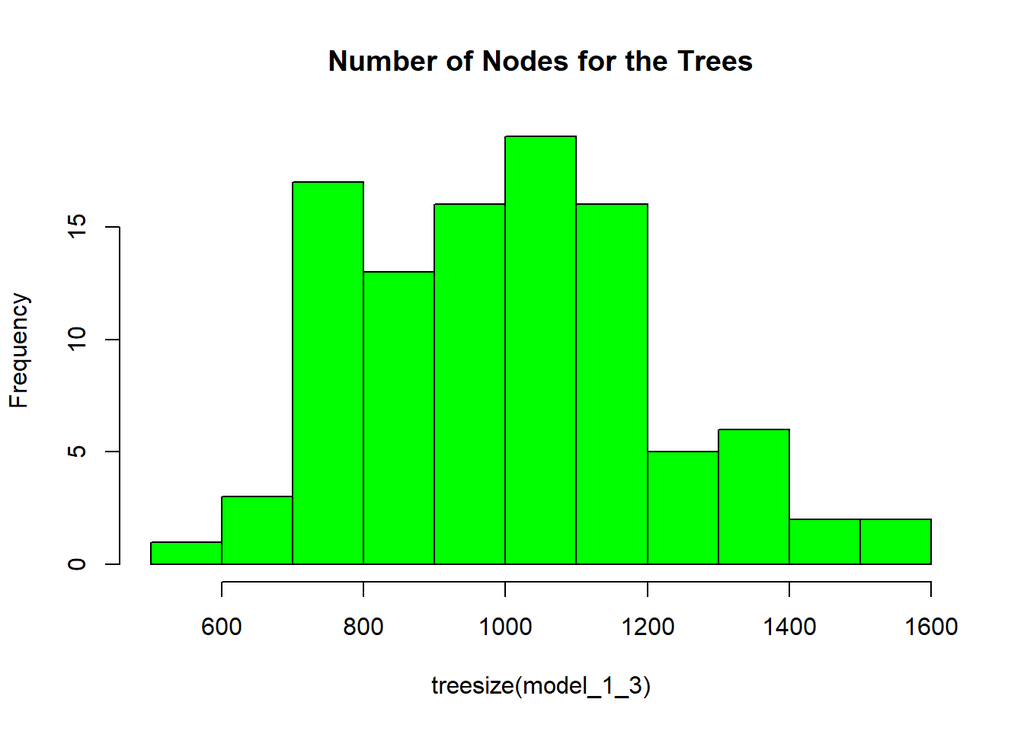

```r
hist(treesize(model_1_3), main = "Number of Nodes for the Trees", col = "green")
```

```r
varImpPlot(model_1_3, sort = TRUE, main = "Variable Importance")
```

[output not shown]

```r
importance(model_1_3)
```

```
##                      MeanDecreaseGini
## NeighbourhoodName         1586.333737
## Primary_Offence             63.024994
## Occurrence_Date            169.763510
## Occurrence_Year             72.263118
## Occurrence_Month           206.415005
## Occurrence_DayOfWeek       152.675406
## Occurrence_Hour            332.518537
## Division                  2018.622879
## City                         4.214652
## Hood_ID                   2553.234293
## Location_Type              250.743714
## Premises_Type              141.421714
## Bike_Make                  124.123655
## Bike_Model                  97.075958
## Bike_Type                  133.186791
## Bike_Colour                100.069529
## Cost_of_Bike               146.377560
## Status                       9.681667
```

Note: During comparing 3 different method cv on random forest models accurracies were same. We will use repeated k-fold cross-validation on random forest using different features

Performing different features(variable combinations) on Random Forest Model

Using all variables

```r
set.seed(999)
data_1<- bt_clean_future_selection

#Random Sampling
Index<- sample(nrow(data_1), floor(0.70*nrow(data_1)))
data_1_train<- data_1[Index,]
data_1_test<- data_1[-Index,]

#Treating train data
data_1_train$Cost_of_Bike[is.na(data_1_train$Cost_of_Bike)]<- mean(data_1_train$Cost_of_Bike,na.rm=TRUE)
data_1_train$Occurrence_Year[data_1_train$Occurrence_Year==2009] <- 2014
data_1_train$Occurrence_Year[data_1_train$Occurrence_Year==2010] <- 2014
data_1_train$Occurrence_Year[data_1_train$Occurrence_Year==2011] <- 2014
data_1_train$Occurrence_Year[data_1_train$Occurrence_Year==2012] <- 2014
data_1_train$Occurrence_Year[data_1_train$Occurrence_Year==2013] <- 2014

ctrl<- trainControl(method = "repeatedcv", number = 10 ,repeats = 10)

#Building model
rf_model_01<- randomForest(Hood_Risk~., data = data_1_train, ntree = 100, trainControl = ctrl, tuneLength = 50)
print(rf_model_01)
```

```
##
## Call:
##  randomForest(formula = Hood_Risk ~ ., data = data_1_train, ntree = 100,      trainControl = ctrl, tuneLength = 50)
##                Type of random forest: classification
##                      Number of trees: 100
## No. of variables tried at each split: 4
##
##         OOB estimate of  error rate: 2.12%
## Confusion matrix:
##           Very Low Low Medium High Very High  class.error
## Very Low       150  37    113   19         1 0.5312500000
## Low              9 580     34   54         5 0.1495601173
## Medium           0   7   1422   36         1 0.0300136426
## High             0   9      5 2537        40 0.0208413740
## Very High        0   0      3    7     12829 0.0007788769
```

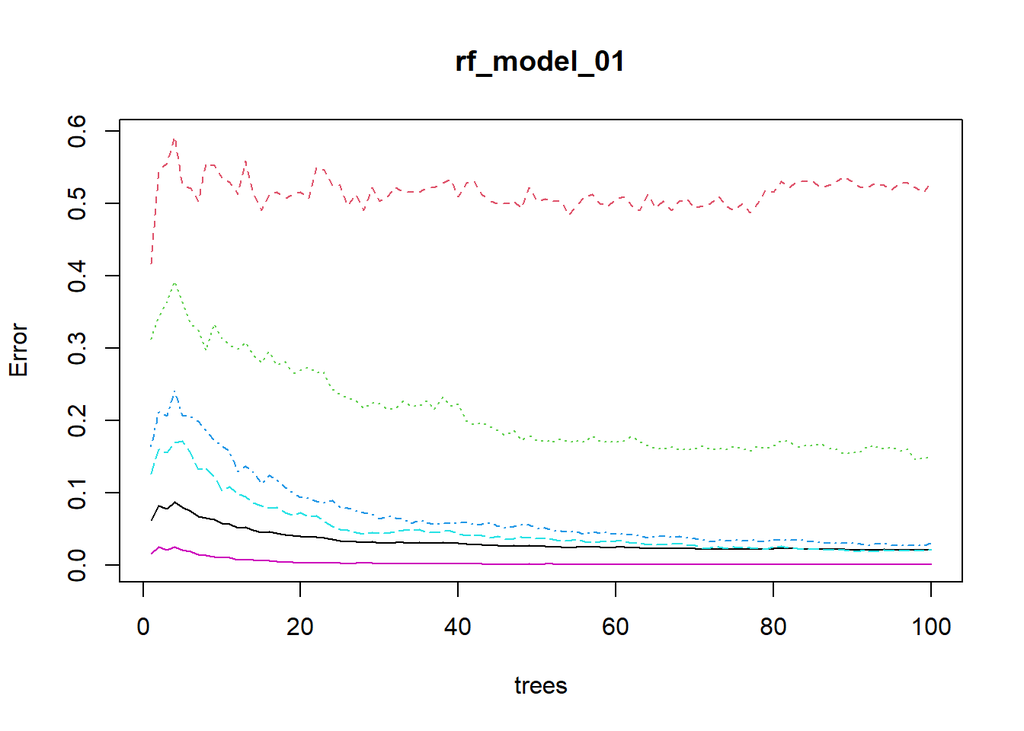

```r
plot(rf_model_01)
```

```r
#Testing Model
risk_pred_rf_model_01<- predict(rf_model_01, data_1_test)

#t<- tuneRF(data_1_train[,-18], data_1_train[,18], stepFactor = 0.5, plot = TRUE, ntreeTry = 200, trace = TRUE, improve = 0.05)
#plot(t)

#Statistics about model
data_1_test$risk_pred_rf_model_01<- risk_pred_rf_model_01
conf_matrix_rf_model_01<- table(data_1_test$Hood_Risk, data_1_test$risk_pred_rf_model_01)
conf_matrix_rf_model_01
```

```
##
##             Very Low  Low Medium High Very High
##   Very Low        53    9     41    3         0
##   Low              5  232     11   28         1
##   Medium           0    0    544    7         4
##   High             0    2      2  949        29
##   Very High        0    0      1    4      5232
```

```r
class_accuarcy_rf_model_01<- sum(diag(conf_matrix_rf_model_01)/sum(conf_matrix_rf_model_01))
class_accuarcy_rf_model_01
```

```
## [1] 0.9794607
```

```r
confusionMatrix(conf_matrix_rf_model_01)
```

```
## Confusion Matrix and Statistics
##
##
##             Very Low  Low Medium High Very High
##   Very Low        53    9     41    3         0
##   Low              5  232     11   28         1
##   Medium           0    0    544    7         4
##   High             0    2      2  949        29
##   Very High        0    0      1    4      5232
##
## Overall Statistics
##
##                Accuracy : 0.9795
##                  95% CI : (0.9759, 0.9826)
##     No Information Rate : 0.7358
##     P-Value [Acc > NIR] : < 2.2e-16
##
##                   Kappa : 0.9527
##
##  Mcnemar's Test P-Value : NA
##
## Statistics by Class:
##
##                      Class: Very Low Class: Low Class: Medium Class: High
## Sensitivity                 0.913793    0.95473       0.90818      0.9576
## Specificity                 0.992534    0.99349       0.99832      0.9946
## Pos Pred Value              0.500000    0.83755       0.98018      0.9664
## Neg Pred Value              0.999291    0.99840       0.99167      0.9932
## Prevalence                  0.008104    0.03395       0.08369      0.1385
## Detection Rate              0.007405    0.03242       0.07601      0.1326
## Detection Prevalence        0.014811    0.03870       0.07755      0.1372
## Balanced Accuracy           0.953164    0.97411       0.95325      0.9761
##                      Class: Very High
## Sensitivity                    0.9935
## Specificity                    0.9974
## Pos Pred Value                 0.9990
## Neg Pred Value                 0.9823
## Prevalence                     0.7358
## Detection Rate                 0.7310
## Detection Prevalence           0.7317
## Balanced Accuracy              0.9954
```

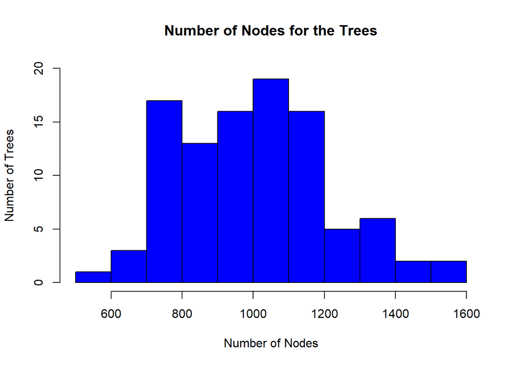

```r
hist(treesize(rf_model_01),ylim = c(0, 20) ,xlab = "Number of Nodes", ylab = "Number of Trees", main = "Number of Nodes for the Trees", col = "blue")
```

```r
varImpPlot(rf_model_01, sort = TRUE, main = "Variable Importance")
```

[output not shown]

```r
importance(rf_model_01)
```

```
##                      MeanDecreaseGini
## NeighbourhoodName         1586.333737
## Primary_Offence             63.024994
## Occurrence_Date            169.763510
## Occurrence_Year             72.263118
## Occurrence_Month           206.415005
## Occurrence_DayOfWeek       152.675406
## Occurrence_Hour            332.518537
## Division                  2018.622879
## City                         4.214652
## Hood_ID                   2553.234293
## Location_Type              250.743714
## Premises_Type              141.421714
## Bike_Make                  124.123655
## Bike_Model                  97.075958
## Bike_Type                  133.186791
## Bike_Colour                100.069529
## Cost_of_Bike               146.377560
## Status                       9.681667
```

No Status and City variables were used

```r
set.seed(999)
data_1<- bt_clean_future_selection

#Random Sampling
Index<- sample(nrow(data_1), floor(0.70*nrow(data_1)))
data_1_train<- data_1[Index,]
data_1_test<- data_1[-Index,]

#Treating train data
data_1_train$Cost_of_Bike[is.na(data_1_train$Cost_of_Bike)]<- mean(data_1_train$Cost_of_Bike,na.rm=TRUE)
data_1_train$Occurrence_Year[data_1_train$Occurrence_Year==2009] <- 2014
data_1_train$Occurrence_Year[data_1_train$Occurrence_Year==2010] <- 2014
data_1_train$Occurrence_Year[data_1_train$Occurrence_Year==2011] <- 2014
data_1_train$Occurrence_Year[data_1_train$Occurrence_Year==2012] <- 2014
data_1_train$Occurrence_Year[data_1_train$Occurrence_Year==2013] <- 2014

ctrl<- trainControl(method = "repeatedcv", number = 10 ,repeats = 10)

#Building model
rf_model_02<- randomForest(Hood_Risk~.-Status-City, data = data_1_train, ntree = 100, trainControl = ctrl, tuneLength = 50)
print(rf_model_02)
```

```
##
## Call:
##  randomForest(formula = Hood_Risk ~ . - Status - City, data = data_1_train,      ntree = 100, trainControl = ctrl, tuneLength = 50)
##                Type of random forest: classification
##                      Number of trees: 100
## No. of variables tried at each split: 4
##
##         OOB estimate of  error rate: 1.39%
## Confusion matrix:
##           Very Low Low Medium High Very High  class.error
## Very Low       181  37     91   11         0 0.4343750000
## Low              3 617     18   41         3 0.0953079179
## Medium           1   2   1445   18         0 0.0143246930
## High             0   3      3 2570        15 0.0081049788
## Very High        0   0      2    1     12836 0.0002336631
```

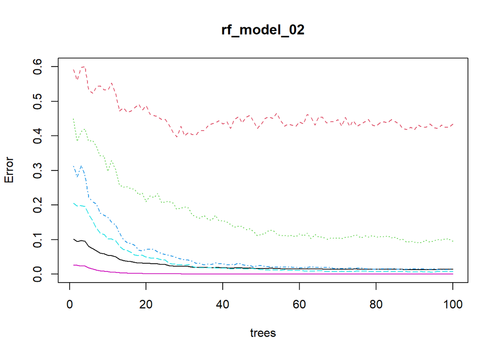

```r
plot(rf_model_02)
```

```r
#Testing Model
risk_pred_rf_model_02<- predict(rf_model_02, data_1_test)


#Statistics about model
data_1_test$risk_pred_rf_model_02<- risk_pred_rf_model_02
conf_matrix_rf_model_02<- table(data_1_test$Hood_Risk, data_1_test$risk_pred_rf_model_02)
conf_matrix_rf_model_02
```

```
##
##             Very Low  Low Medium High Very High
##   Very Low        66    5     35    0         0
##   Low              1  260      6   10         0
##   Medium           0    0    551    2         2
##   High             0    2      1  959        20
##   Very High        0    0      0    1      5236
```

```r
class_accuarcy_rf_model_02<- sum(diag(conf_matrix_rf_model_02)/sum(conf_matrix_rf_model_02))
class_accuarcy_rf_model_02
```

```
## [1] 0.9881235
```

```r
confusionMatrix(conf_matrix_rf_model_02)
```

```
## Confusion Matrix and Statistics
##
##
##             Very Low  Low Medium High Very High
##   Very Low        66    5     35    0         0
##   Low              1  260      6   10         0
##   Medium           0    0    551    2         2
##   High             0    2      1  959        20
##   Very High        0    0      0    1      5236
##
## Overall Statistics
##
##                Accuracy : 0.9881
##                  95% CI : (0.9853, 0.9905)
##     No Information Rate : 0.7347
##     P-Value [Acc > NIR] : < 2.2e-16
##
##                   Kappa : 0.9727
##
##  Mcnemar's Test P-Value : NA
##
## Statistics by Class:
##
##                      Class: Very Low Class: Low Class: Medium Class: High
## Sensitivity                 0.985075    0.97378       0.92917      0.9866
## Specificity                 0.994358    0.99753       0.99939      0.9963
## Pos Pred Value              0.622642    0.93863       0.99279      0.9766
## Neg Pred Value              0.999858    0.99898       0.99364      0.9979
## Prevalence                  0.009361    0.03731       0.08286      0.1358
## Detection Rate              0.009222    0.03633       0.07699      0.1340
## Detection Prevalence        0.014811    0.03870       0.07755      0.1372
## Balanced Accuracy           0.989716    0.98566       0.96428      0.9915
##                      Class: Very High
## Sensitivity                    0.9958
## Specificity                    0.9995
## Pos Pred Value                 0.9998
## Neg Pred Value                 0.9885
## Prevalence                     0.7347
## Detection Rate                 0.7316
## Detection Prevalence           0.7317
## Balanced Accuracy              0.9976
```

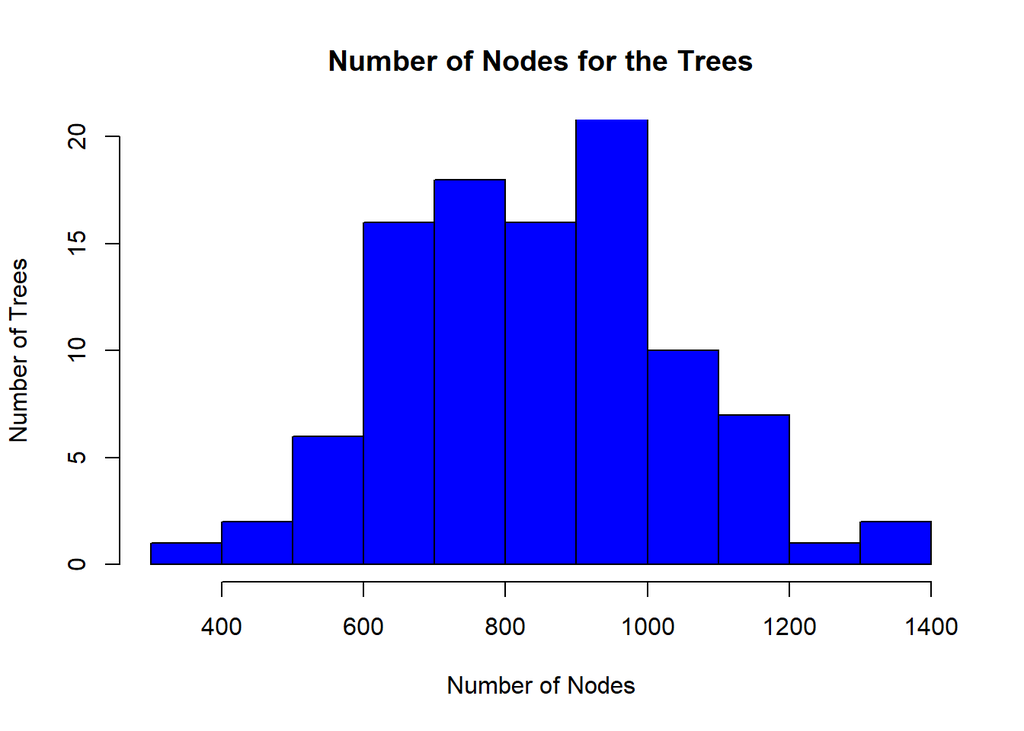

```r
hist(treesize(rf_model_02),ylim = c(0, 20) ,xlab = "Number of Nodes", ylab = "Number of Trees", main = "Number of Nodes for the Trees", col = "blue")
```

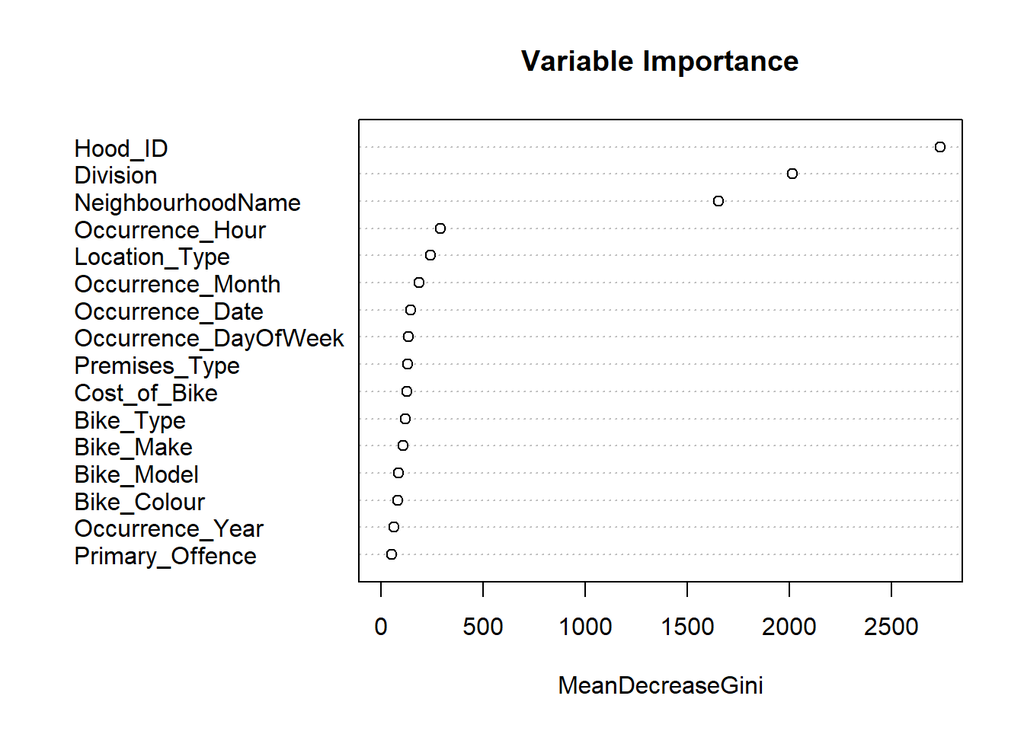

```r
varImpPlot(rf_model_02, sort = TRUE, main = "Variable Importance")
```

```r
importance(rf_model_02)
```

```
##                      MeanDecreaseGini
## NeighbourhoodName          1653.51552
## Primary_Offence              49.59059
## Occurrence_Date             142.62739
## Occurrence_Year              59.99976
## Occurrence_Month            184.51692
## Occurrence_DayOfWeek        134.04114
## Occurrence_Hour             290.06681
## Division                   2013.42737
## Hood_ID                    2737.62459
## Location_Type               241.81012
## Premises_Type               130.73854
## Bike_Make                   105.26563
## Bike_Model                   85.37670
## Bike_Type                   116.16102
## Bike_Colour                  82.25645
## Cost_of_Bike                124.05340
```

No Status No City No Primary_Offence variables were used

```r
set.seed(999)
data_1<- bt_clean_future_selection

#Random Sampling
Index<- sample(nrow(data_1), floor(0.70*nrow(data_1)))
data_1_train<- data_1[Index,]
data_1_test<- data_1[-Index,]

#Treating train data
data_1_train$Cost_of_Bike[is.na(data_1_train$Cost_of_Bike)]<- mean(data_1_train$Cost_of_Bike,na.rm=TRUE)
data_1_train$Occurrence_Year[data_1_train$Occurrence_Year==2009] <- 2014
data_1_train$Occurrence_Year[data_1_train$Occurrence_Year==2010] <- 2014
data_1_train$Occurrence_Year[data_1_train$Occurrence_Year==2011] <- 2014
data_1_train$Occurrence_Year[data_1_train$Occurrence_Year==2012] <- 2014
data_1_train$Occurrence_Year[data_1_train$Occurrence_Year==2013] <- 2014

ctrl<- trainControl(method = "repeatedcv", number = 10 ,repeats = 10)

#Building model
rf_model_03<- randomForest(Hood_Risk~.-Status-City-Primary_Offence, data = data_1_train, ntree = 100, trainControl = ctrl, tuneLength = 50)
print(rf_model_03)
```

```
##
## Call:
##  randomForest(formula = Hood_Risk ~ . - Status - City - Primary_Offence,      data = data_1_train, ntree = 100, trainControl = ctrl, tuneLength = 50)
##                Type of random forest: classification
##                      Number of trees: 100
## No. of variables tried at each split: 3
##
##         OOB estimate of  error rate: 2.78%
## Confusion matrix:
##           Very Low Low Medium High Very High class.error
## Very Low       131  44    123   18         4  0.59062500
## Low              8 527     53   86         8  0.22727273
## Medium           1  10   1410   43         2  0.03819918
## High             0  10     10 2506        65  0.03280587
## Very High        0   0      4    9     12826  0.00101254
```

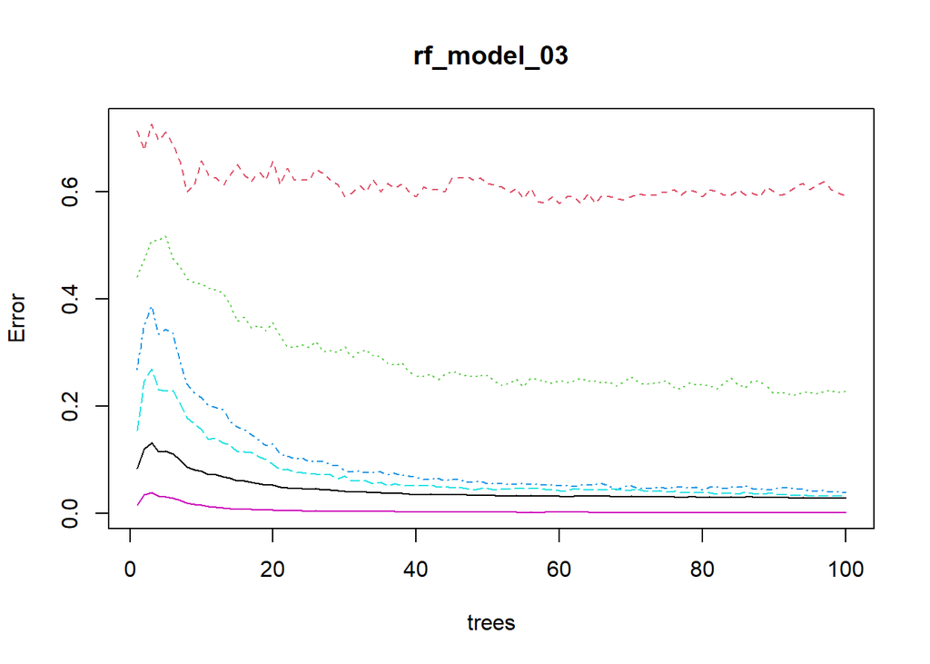

```r
plot(rf_model_03)
```

```r
#Testing Model
risk_pred_rf_model_03<- predict(rf_model_03, data_1_test)


#Statistics about model
data_1_test$risk_pred_rf_model_03<- risk_pred_rf_model_03
conf_matrix_rf_model_03<- table(data_1_test$Hood_Risk, data_1_test$risk_pred_rf_model_03)
conf_matrix_rf_model_03
```

```
##
##             Very Low  Low Medium High Very High
##   Very Low        47   12     41    6         0
##   Low              2  223     16   36         0
##   Medium           0    0    537   16         2
##   High             0    2      6  932        42
##   Very High        0    0      1    5      5231
```

```r
class_accuarcy_rf_model_03<- sum(diag(conf_matrix_rf_model_03)/sum(conf_matrix_rf_model_03))
class_accuarcy_rf_model_03
```

```
## [1] 0.9738717
```

```r
confusionMatrix(conf_matrix_rf_model_03)
```

```
## Confusion Matrix and Statistics
##
##
##             Very Low  Low Medium High Very High
##   Very Low        47   12     41    6         0
##   Low              2  223     16   36         0
##   Medium           0    0    537   16         2
##   High             0    2      6  932        42
##   Very High        0    0      1    5      5231
##
## Overall Statistics
##
##                Accuracy : 0.9739
##                  95% CI : (0.9699, 0.9774)
##     No Information Rate : 0.737
##     P-Value [Acc > NIR] : < 2.2e-16
##
##                   Kappa : 0.9398
##
##  Mcnemar's Test P-Value : NA
##
## Statistics by Class:
##
##                      Class: Very Low Class: Low Class: Medium Class: High
## Sensitivity                 0.959184    0.94093       0.89351      0.9367
## Specificity                 0.991699    0.99220       0.99725      0.9919
## Pos Pred Value              0.443396    0.80505       0.96757      0.9491
## Neg Pred Value              0.999716    0.99797       0.99031      0.9898
## Prevalence                  0.006846    0.03311       0.08397      0.1390
## Detection Rate              0.006567    0.03116       0.07503      0.1302
## Detection Prevalence        0.014811    0.03870       0.07755      0.1372
## Balanced Accuracy           0.975442    0.96656       0.94538      0.9643
##                      Class: Very High
## Sensitivity                    0.9917
## Specificity                    0.9968
## Pos Pred Value                 0.9989
## Neg Pred Value                 0.9771
## Prevalence                     0.7370
## Detection Rate                 0.7309
## Detection Prevalence           0.7317
## Balanced Accuracy              0.9942
```

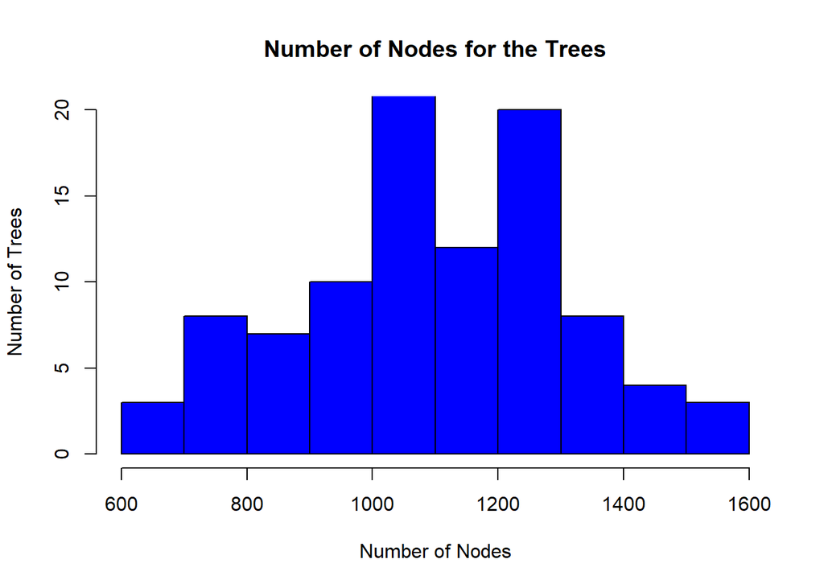

```r
hist(treesize(rf_model_03),ylim = c(0, 20) ,xlab = "Number of Nodes", ylab = "Number of Trees", main = "Number of Nodes for the Trees", col = "blue")
```

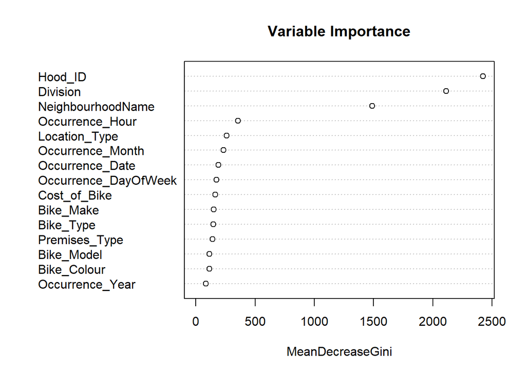

```r
varImpPlot(rf_model_03, sort = TRUE, main = "Variable Importance")
```

```r
importance(rf_model_03)
```

```
##                      MeanDecreaseGini
## NeighbourhoodName          1487.39842
## Occurrence_Date             189.01473
## Occurrence_Year              85.87218
## Occurrence_Month            232.72640
## Occurrence_DayOfWeek        172.16511
## Occurrence_Hour             355.44666
## Division                   2113.93459
## Hood_ID                    2422.26323
## Location_Type               258.52507
## Premises_Type               139.72060
## Bike_Make                   149.38460
## Bike_Model                  115.62196
## Bike_Type                   147.06543
## Bike_Colour                 113.53097
## Cost_of_Bike                163.97425
```

No Status No City No Primary_Offence No Occurrence_Year Variables were used

```r
set.seed(999)
data_1<- bt_clean_future_selection

#Random Sampling
Index<- sample(nrow(data_1), floor(0.70*nrow(data_1)))
data_1_train<- data_1[Index,]
data_1_test<- data_1[-Index,]

#Treating train data
data_1_train$Cost_of_Bike[is.na(data_1_train$Cost_of_Bike)]<- mean(data_1_train$Cost_of_Bike,na.rm=TRUE)
data_1_train$Occurrence_Year[data_1_train$Occurrence_Year==2009] <- 2014
data_1_train$Occurrence_Year[data_1_train$Occurrence_Year==2010] <- 2014
data_1_train$Occurrence_Year[data_1_train$Occurrence_Year==2011] <- 2014
data_1_train$Occurrence_Year[data_1_train$Occurrence_Year==2012] <- 2014
data_1_train$Occurrence_Year[data_1_train$Occurrence_Year==2013] <- 2014

ctrl<- trainControl(method = "repeatedcv", number = 10 ,repeats = 10)

#Building model
rf_model_04<- randomForest(Hood_Risk~.-Status-City-Primary_Offence-Occurrence_Year, data = data_1_train, ntree = 100, trainControl = ctrl, tuneLength = 50)
print(rf_model_04)
```

```
##
## Call:
##  randomForest(formula = Hood_Risk ~ . - Status - City - Primary_Offence -      Occurrence_Year, data = data_1_train, ntree = 100, trainControl = ctrl,      tuneLength = 50)
##                Type of random forest: classification
##                      Number of trees: 100
## No. of variables tried at each split: 3
##
##         OOB estimate of  error rate: 2.02%
## Confusion matrix:
##           Very Low Low Medium High Very High  class.error
## Very Low       147  48    110   15         0 0.5406250000
## Low             10 589     35   44         4 0.1363636364
## Medium           0   5   1417   40         4 0.0334242838
## High             0   5      4 2550        32 0.0158240062
## Very High        0   0      2    3     12834 0.0003894384
```

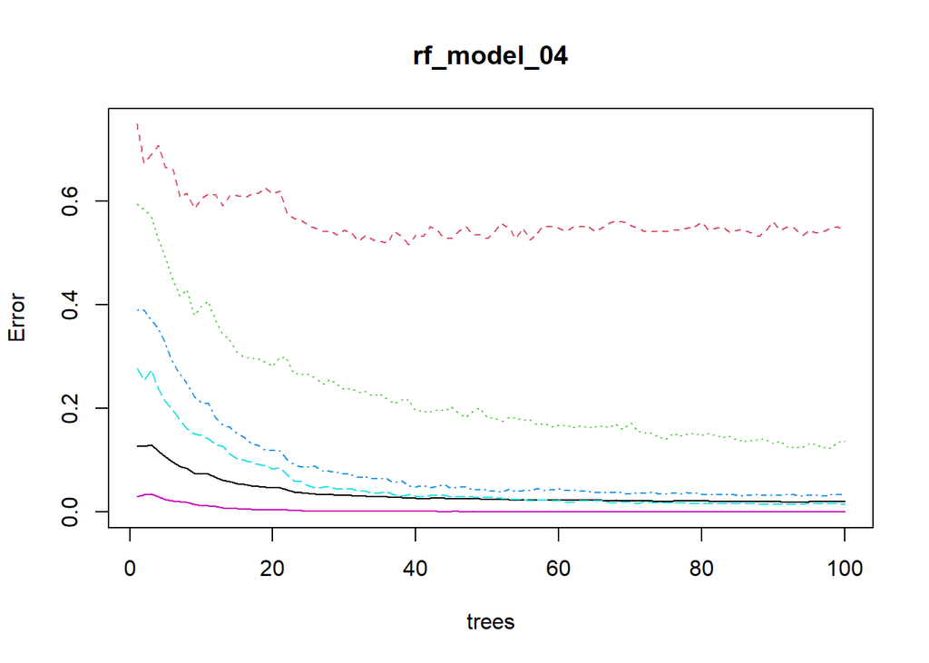

```r
plot(rf_model_04)
```